# Work Attrition Analysis - A Data Science Project

Stefan Anca

2024-08-13

# 1 - INTRODUCTION.

## 1.1 - R Markdown.

If the project is visualized on a mobile device, the text in the code blocks may extend beyond the edges. When viewing this project on a mobile device, it is recommended to hold it in a **horizontal position**, as less text will extend beyond the edges in this orientation.

## 1.2 - Goal of the project.

The objective of this project will be to describe and explain how job abandonment occurs. Associations between different variables and job abandonment will be sought to describe when this occurs and to establish possible explanations for the phenomenon. Multiple techniques will be used for variable manipulation, data cleaning, data exploration, and clustering models to try to identify specific groups. The main goal is to explore the functioning of the algorithms and demonstrate ways of working with data at the time that we attempt a specific goal, rather than creating the best model.

Some steps in this project are designed to showcase a broad range of data science techniques, even if not all are directly interconnected or essential for the final outcome. Certain analyses were conducted to enhance understanding of the problem, and some steps were taken to prepare the data for potential future scenarios. This approach was intentionally chosen to demonstrate a variety of data science methods and skills.

## 1.3 - Dataset description.

The selected dataset, which comes from the field of human resource management, is named “Employee Attrition and Factors”. Each row corresponds to a specific employee of the company and includes some demographic variables such as age and education level (among others) containing additionally multiple variables describing the job position, such as the frequency of work-related travel, the department in which the employee works, and the distance between the workplace and the employee’s home. Therefore, this dataset provides data that allows for the analysis of job abandonment from both a professional and personal perspective, making it ideal for the initial objective of describing and explaining job abandonment.

The dataset is available in Kaeggle: https://www.kaggle.com/datasets/thedevastator/employee-attrition-and-factors

The name and meaning/description of the variables are presented below:

**Age**: The age of the employee. (Numerical)

**Attrition**: Whether or not the employee has left the organization. (Categorical)

**BusinessTravel**: The frequency of business travel for the employee. (Categorical)

**DailyRate**: The daily rate of pay for the employee. (Numerical)

**Department**: The department the employee works in. (Categorical)

**DistanceFromHome**: The distance from home in miles for the employee. (Numerical)

**Education**: The level of education achieved by the employee. (Categorical)

**EducationField**: The field of study for the employee’s education. (Categorical)

**EmployeeCount**: The total number of employees in the organization. (Numerical)

**EmployeeNumber**: A unique identifier for each employee profile. (Numerical)

**EnvironmentSatisfaction**: The employee’s satisfaction with their work environment. (Categorical)

**Gender**: The gender of the employee. (Categorical)

**HourlyRate**: The hourly rate of pay for the employee. (Numerical)

**JobInvolvement**: The level of involvement required for the employee’s job. (Categorical)

**JobLevel**: The job level of the employee. (Categorical)

**JobRole**: The role of the employee in the organization. (Categorical)

**JobSatisfaction**: The employee’s satisfaction with their job. (Categorical)

**MaritalStatus**: The marital status of the employee. (Categorical)

**MonthlyIncome**: The monthly income of the employee. (Numerical)

**MonthlyRate**: The monthly rate of pay for the employee. (Numerical)

**NumCompaniesWorked**: The number of companies the employee has worked for. (Numerical)

**Over18**: Whether or not the employee is over 18. (Categorical)

**OverTime**: Whether or not the employee works overtime. (Categorical)

**PercentSalaryHike**: The percentage of salary hike for the employee. (Numerical)

**PerformanceRating**: The performance rating of the employee. (Categorical)

**RelationshipSatisfaction**: The employee’s satisfaction with their relationships. (Categorical)

**StandardHours**: The standard hours of work for the employee. (Numerical)

**StockOptionLevel**: The stock option level of the employee. (Numerical)

**TotalWorkingYears**: The total number of years the employee has worked. (Numerical)

**TrainingTimesLastYear**: The number of times the employee was taken for training in the last year. (Numerical)

**WorkLifeBalance**: The employee’s perception of their work-life balance. (Categorical)

**YearsAtCompany**: The number of years the employee has been with the company. (Numerical)

**YearsInCurrentRole**: The number of years the employee has been in their current role. (Numerical)

**YearsSinceLastPromotion**: The number of years since the employee’s last promotion. (Numerical)

**YearsWithCurrManager**: The number of years the employee has been with their current manager. (Numerical)

# 2. EXPLORATORY DATA ANALYSIS (EDA).

## 2.1 - Number of variables of each type.

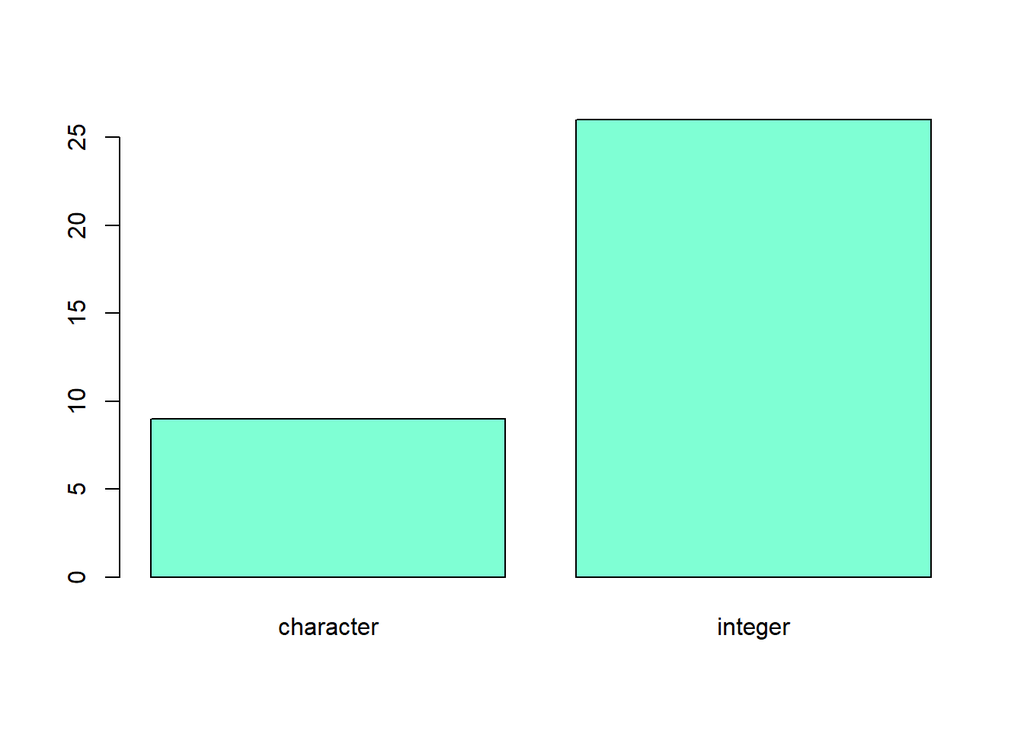

```r
# Load the data
HR_data <- read.csv("WokingAttrition.csv")

# Show how many variables of each class there are
barplot(table(sapply(HR_data, class)), col = "aquamarine")
```

## 2.2 - Analysing character variables.

Since we have multiple variables in the dataset, we will try to make the exploratory analysis more manageable. First, we will focus on the character variables, and after on the numeric variables.

```r
# Using 'sapply' we get a vector showing which columns are character
char_columns <- sapply(HR_data, class) == "character"
# We save in a dataframe the character variables
character_var <- HR_data[char_columns]
# We show their names
colnames(character_var)
```

```
## [1] "Attrition"      "BusinessTravel" "Department"     "EducationField" "Gender"         "JobRole"
## [7] "MaritalStatus"  "Over18"         "OverTime"
```

```r
# We show the number of unique values of each variable
sapply(character_var, function(x) length(unique(x)))
```

```
##      Attrition BusinessTravel     Department EducationField         Gender        JobRole  MaritalStatus
##              2              3              3              6              2              9              3
##         Over18       OverTime
##              1              2
```

### 2.1.1 - Character variables with 1 cathegory.

Only observing the number of unique values we can observe some interesting things. First, “Over18” has only 1 unique value. In addition, there are multiple variables with only 2 or 3 unique values, and just 2 variables have more than 3 unique values. We will explore this variables starting from those that have less unique values to those that have more.

```r
# We show the unique value of the variable 'Over18'
unique(HR_data$Over18)
```

```
## [1] "Y"
```

The unique value is “Y”. This indicates that all individuals are adults. In the data cleaning process, we will discard this variable, as is a constant that we already know from this point about the dataset.

### 2.1.2 - Character variables with 2 or 3 cathegories.

Now, we will make a graphical representation of the variables with 2 and 3 unique values.

First, we preparate the data for it.

```r
# We load some packages necesary for the visualisation and data manipulation
library(ggplot2)
library(dplyr)
library(tidyr)
# We save in a data frame the variable with 2 or 3 unique values
data_2_3_unique <- HR_data[c("Attrition", "Gender", "OverTime", "BusinessTravel", "Department", "MaritalStatus")]

# We transform this data to a long format
data_long <- data_2_3_unique %>%
  pivot_longer(cols = everything(), names_to = "Variable", values_to = "Category") %>%

  #We count how many times appears each category of each variable
  count(Variable, Category) %>%
  group_by(Variable) %>% # We group by variable
  mutate(Prop=n/sum(n)) # We calculate the proportion of each category

# We show the result
data_long
```

```
## # A tibble: 15 × 4
## # Groups:   Variable [6]
##    Variable       Category                   n   Prop
##    <chr>          <chr>                  <int>  <dbl>
##  1 Attrition      No                      1233 0.839
##  2 Attrition      Yes                      237 0.161
##  3 BusinessTravel Non-Travel               150 0.102
##  4 BusinessTravel Travel_Frequently        277 0.188
##  5 BusinessTravel Travel_Rarely           1043 0.710
##  6 Department     Human Resources           63 0.0429
##  7 Department     Research & Development   961 0.654
##  8 Department     Sales                    446 0.303
##  9 Gender         Female                   588 0.4
## 10 Gender         Male                     882 0.6
## 11 MaritalStatus  Divorced                 327 0.222
## 12 MaritalStatus  Married                  673 0.458
## 13 MaritalStatus  Single                   470 0.320
## 14 OverTime       No                      1054 0.717
## 15 OverTime       Yes                      416 0.283
```

**GRAPHICAL REPRESENTATION OF VARIABLES WITH 2 AND 3 CATHEGORIES.**

Now we are going to represent this data. On the x-axis, will be included each variable, and on the y-axis, the height represents the proportion of each category. For each variable, we will fill the figure based on the proportion that each category appears within the variable. We will create a bar chart using the values displayed in the dataframe.

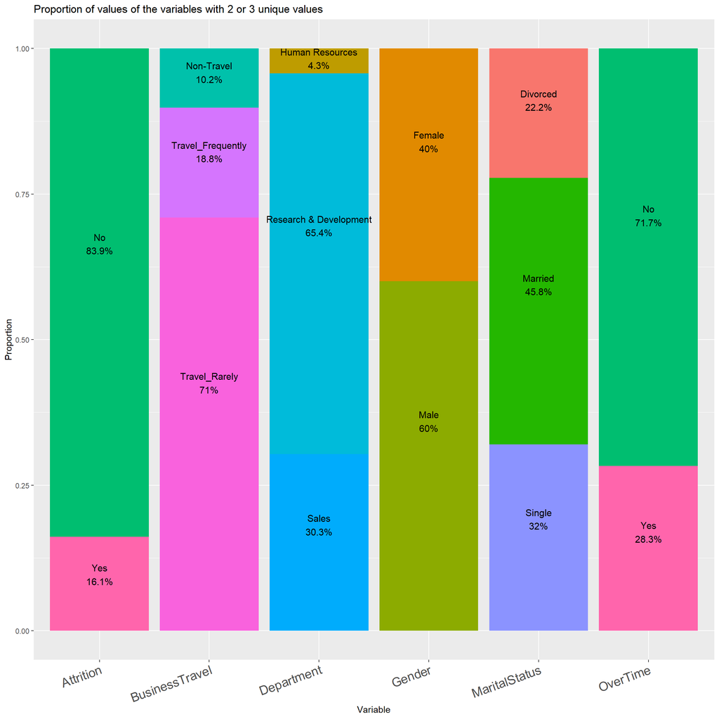

```r
# Initialization of ggplot graph
ggplot(data_long, aes(x = Variable, y = Prop, fill = Category)) + geom_bar(stat = "identity") +

# Text is added to axes, title, and for each category represented
geom_text(aes(label = paste0(Category, "\n", round(Prop * 100, 1), "%")), position = position_stack(vjust = 0.6),
    size = 4) + labs(y = "Proportion", title = "Proportion of values of the variables with 2 or 3 unique values") +

# The legend text will have an angle
theme(legend.position = "none", axis.text.x = element_text(angle = 20, hjust = 1, size = 15),
    )
```

We can observe several things. First, for binary variables, in all cases, one of the variables is more dominant than the other. On the other hand, regarding the variables with 3 categories, first, in the ‘Department’ variable, there are only 3 unique values. This indicates that the sample is not representative of all types of jobs that might exist, but rather that it likely comes from a specific sector. Additionally, the ‘Human Resources’ category is underrepresented (only 4.3% of the cases).Regarding ‘BusinessTravel,’ we see a clear predominance of people who rarely travel over those who travel frequently or do not travel at all. Finally, concerning the ‘MaritalStatus’ variable, there is some balance between the proportions of the 3 categories, with only a slight predominance of the ‘Married’ category.

### 2.1.3 - Other character variables.

After analyzing the character variables with little unique values, we will analyse the others character variables.

```r
# We save in a dataframe the character variables that we didn't analysed
rest_character_var <- HR_data[c("EducationField", "JobRole")]

# We will se a frequency table for each variable
data.frame(table(rest_character_var[1]))
```

```
##     EducationField Freq
## 1  Human Resources   27
## 2    Life Sciences  606
## 3        Marketing  159
## 4          Medical  464
## 5            Other   82
## 6 Technical Degree  132
```

```r
data.frame(table(rest_character_var[2]))
```

```
##                     JobRole Freq
## 1 Healthcare Representative  131
## 2           Human Resources   52
## 3     Laboratory Technician  259
## 4                   Manager  102
## 5    Manufacturing Director  145
## 6         Research Director   80
## 7        Research Scientist  292
## 8           Sales Executive  326
## 9      Sales Representative   83
```

For both variables, the categories are limited to a really specific field. It seems as though this data is related to the healthcare sector, and includes some complementary departments like Marketing or Human Resources. The number of employees in each category varies significantly across all categories.

## 2.2 - Cathegoric variables stored as numeric.

Now we will start analyzing the numeric variables. First we will analyze some variables that were marked as categorical in the previously created variable dictionary, but which we did not find among the character class variables, specifically:

Education, EnvironmentSatisfaction, JobInvolvement, JobLevel, JobSatisfaction.

```r
# We create a vector of characters containing the name of these variables
names <- c("Education", "EnvironmentSatisfaction", "JobInvolvement", "JobLevel", "JobSatisfaction")
# We create a data frame which includes only these variables using the vector
df_aux <- HR_data[names]

# We observe the structure of this data frame
str(df_aux)
```

```
## 'data.frame':    1470 obs. of  5 variables:
##  $ Education              : int  2 1 2 4 1 2 3 1 3 3 ...
##  $ EnvironmentSatisfaction: int  2 3 4 4 1 4 3 4 4 3 ...
##  $ JobInvolvement         : int  3 2 2 3 3 3 4 3 2 3 ...
##  $ JobLevel               : int  2 2 1 1 1 1 1 1 3 2 ...
##  $ JobSatisfaction        : int  4 2 3 3 2 4 1 3 3 3 ...
```

In all these cases, these are variables whose values are encoded as integers, but on the download page, they are recorded as categorical. Therefore, the numbers probably represent categories whose values we cannot necessarily be treated as continuous. Given the names, descriptions and data type of the variables, we should probably interpret these values as ordinal. In other words, with these variables, we can determine in which observation there are higher levels of a certain variable, but we cannot make arithmetic comparisons between the different levels (for example, we cannot say that 2 represents double of 1 in a specific variable).

We will create an histogram in order to understand how this variables are.

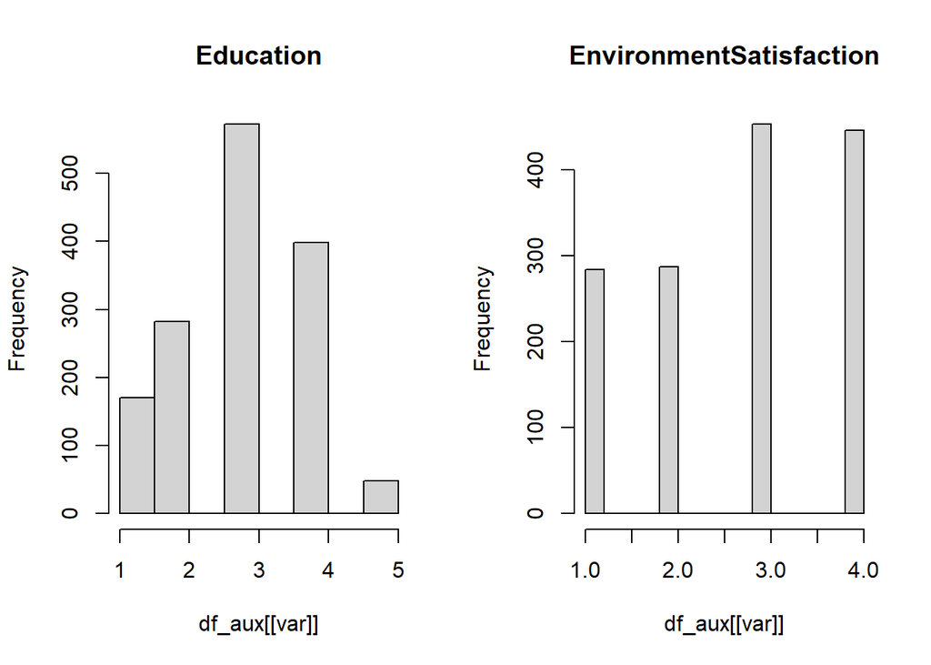

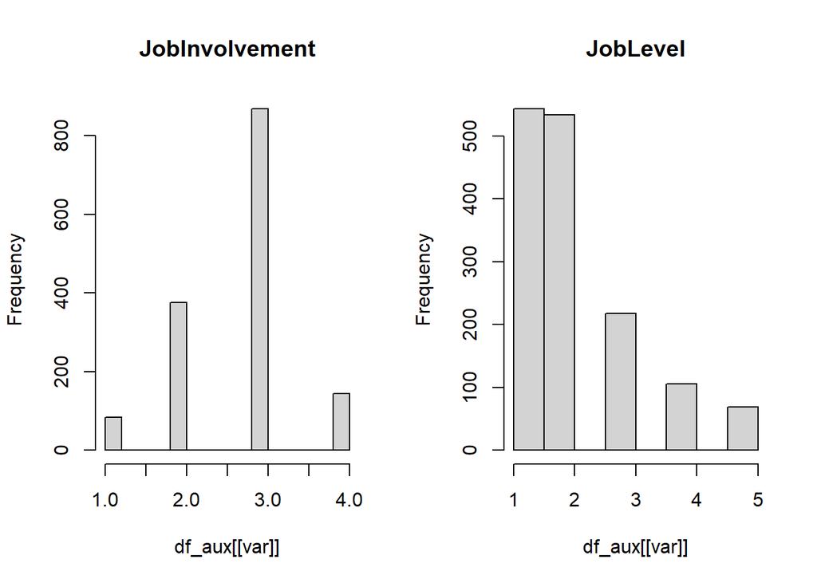

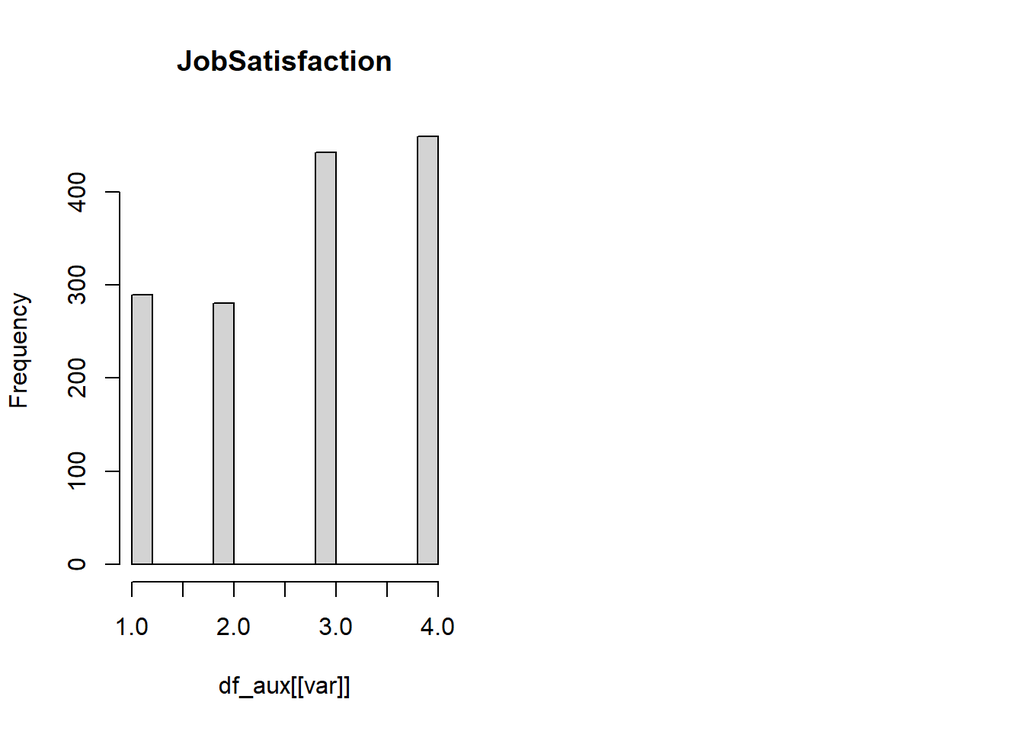

```r
par(mfrow = c(1, 2))
# We iterate over the names of the auxiliar data frame previously created
for (var in colnames(df_aux)) {
    # An histogram is created for each iterated variable
    hist(df_aux[[var]], main = var)
}
```

We find very limited ranges for these variables. For all the values of the variables, there are bars with a minimum number of observations so that they are identifiable. The only issue we could point out is that since there are no labels showing the meaning of each value, we cannot distinguish whether the maximum and minimum values are the theoretical of the variable, or just the maximums/minimums within this sample. To address this issue, when we will prepare the data, we will create some variables from these to allow us to establish clear differences between the subjects if we use these variables.

## 2.3 - Other numeric variables.

### 2.3.1 - General exploration.

Now we will analyse the rest of the numeric variables.

```r
# We create a dataframe with only the numeric variables
numeric_var <- HR_data[sapply(HR_data, FUN = is.numeric)]
# We exclude the ones that were truly categorical but were marked as numeric.
indices_to_eliminate <- match(names, names(numeric_var))
numeric_var <- numeric_var[-indices_to_eliminate]

# We make a summary of these variables
summary(numeric_var)
```

```
##       Age          DailyRate      DistanceFromHome EmployeeCount EmployeeNumber     HourlyRate
##  Min.   :18.00   Min.   : 102.0   Min.   : 1.000   Min.   :1     Min.   :   1.0   Min.   : 30.00
##  1st Qu.:30.00   1st Qu.: 465.0   1st Qu.: 2.000   1st Qu.:1     1st Qu.: 491.2   1st Qu.: 48.00
##  Median :36.00   Median : 802.0   Median : 7.000   Median :1     Median :1020.5   Median : 66.00
##  Mean   :36.92   Mean   : 802.5   Mean   : 9.193   Mean   :1     Mean   :1024.9   Mean   : 65.89
##  3rd Qu.:43.00   3rd Qu.:1157.0   3rd Qu.:14.000   3rd Qu.:1     3rd Qu.:1555.8   3rd Qu.: 83.75
##  Max.   :60.00   Max.   :1499.0   Max.   :29.000   Max.   :1     Max.   :2068.0   Max.   :100.00
##  MonthlyIncome    MonthlyRate    NumCompaniesWorked PercentSalaryHike PerformanceRating
##  Min.   : 1009   Min.   : 2094   Min.   :0.000      Min.   :11.00     Min.   :3.000
##  1st Qu.: 2911   1st Qu.: 8047   1st Qu.:1.000      1st Qu.:12.00     1st Qu.:3.000
##  Median : 4919   Median :14236   Median :2.000      Median :14.00     Median :3.000
##  Mean   : 6503   Mean   :14313   Mean   :2.693      Mean   :15.21     Mean   :3.154
##  3rd Qu.: 8379   3rd Qu.:20462   3rd Qu.:4.000      3rd Qu.:18.00     3rd Qu.:3.000
##  Max.   :19999   Max.   :26999   Max.   :9.000      Max.   :25.00     Max.   :4.000
##  RelationshipSatisfaction StandardHours StockOptionLevel TotalWorkingYears TrainingTimesLastYear
##  Min.   :1.000            Min.   :80    Min.   :0.0000   Min.   : 0.00     Min.   :0.000
##  1st Qu.:2.000            1st Qu.:80    1st Qu.:0.0000   1st Qu.: 6.00     1st Qu.:2.000
##  Median :3.000            Median :80    Median :1.0000   Median :10.00     Median :3.000
##  Mean   :2.712            Mean   :80    Mean   :0.7939   Mean   :11.28     Mean   :2.799
##  3rd Qu.:4.000            3rd Qu.:80    3rd Qu.:1.0000   3rd Qu.:15.00     3rd Qu.:3.000
##  Max.   :4.000            Max.   :80    Max.   :3.0000   Max.   :40.00     Max.   :6.000
##  WorkLifeBalance YearsAtCompany   YearsInCurrentRole YearsSinceLastPromotion YearsWithCurrManager
##  Min.   :1.000   Min.   : 0.000   Min.   : 0.000     Min.   : 0.000          Min.   : 0.000
##  1st Qu.:2.000   1st Qu.: 3.000   1st Qu.: 2.000     1st Qu.: 0.000          1st Qu.: 2.000
##  Median :3.000   Median : 5.000   Median : 3.000     Median : 1.000          Median : 3.000
##  Mean   :2.761   Mean   : 7.008   Mean   : 4.229     Mean   : 2.188          Mean   : 4.123
##  3rd Qu.:3.000   3rd Qu.: 9.000   3rd Qu.: 7.000     3rd Qu.: 3.000          3rd Qu.: 7.000
##  Max.   :4.000   Max.   :40.000   Max.   :18.000     Max.   :15.000          Max.   :17.000
```

There are several things we can observe in this summary.

**- Variables with the same value in all observations:**

There are two cases where this occurs: EmployeeCount and StandardHours.

In the data cleaning step of this data mining process, we will discard these variables since they are not useful for model development (because there is no variability in their values, making it impossible to distinguish cases using these variables).

**- Other variables that also seem ordinal rather than quantitative:**

The variables shown in this summary that appear to be ordinal are: RelationshipSatisfaction, WorkLifeBalance, PerformanceRating, StockOptionLevel.

In these cases, the maximum and minimum values are between 0 and 4. Additionally, all summary statistics, except for the mean, are integers, and if we consider their names and definitions, in none of the cases can the values be interpreted as a specific quantity of a magnitude (the names do not refer to specific physical objects that can be measured directly).

### 2.3.2 - Variables that seem cathegoric, but are stored and described as numeric.

Next, we will display histograms of all these variables to see their distributions.

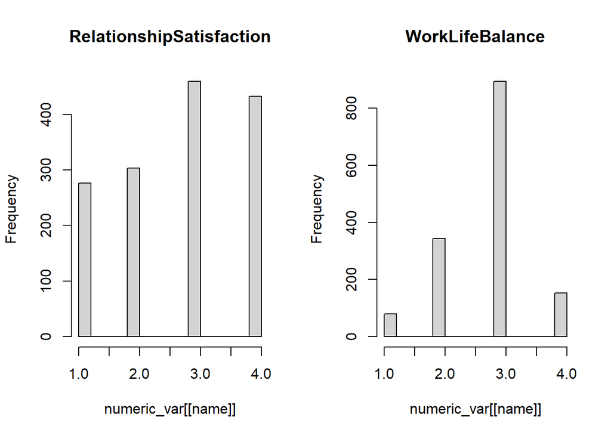

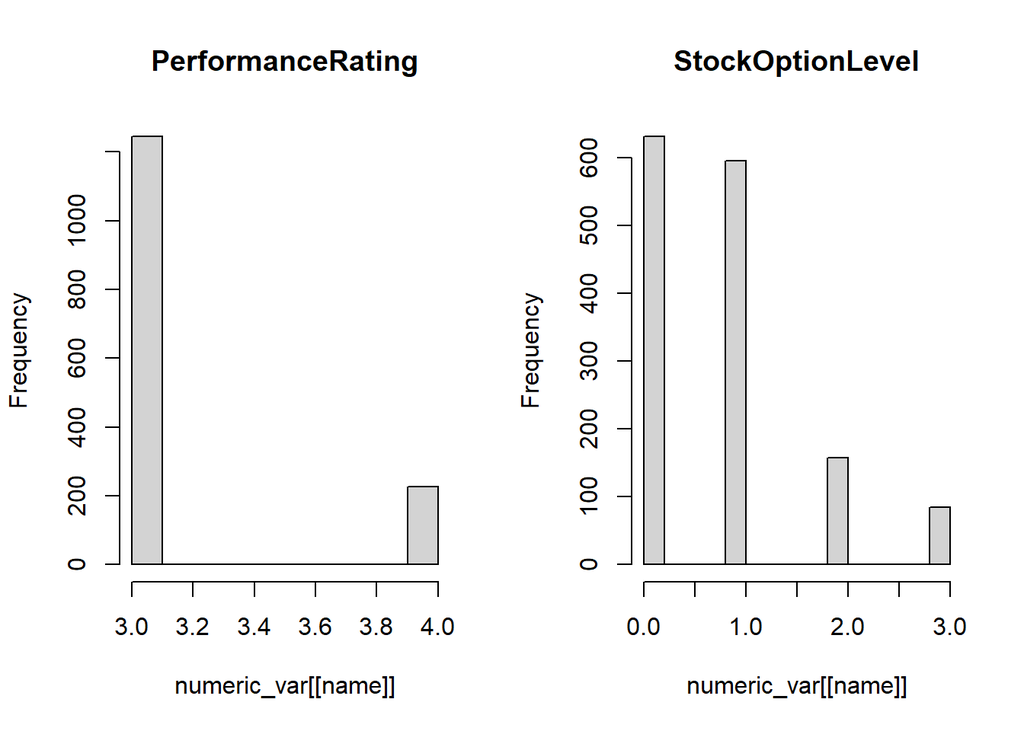

```r
par(mfrow = c(1, 2))
# We save in a vector the names of these variables
ordinal_names <- c("RelationshipSatisfaction", "WorkLifeBalance", "PerformanceRating", "StockOptionLevel")
# We iterate over these names
for (name in ordinal_names) {
    # For each name, an histogram is created with the column of the dataset with tha same
    # name
    hist(numeric_var[[name]], main = name)
}
```

```r
# We also get the number of unique values of each variable
sapply(numeric_var[ordinal_names], function(x) length(unique(x)))
```

```
## RelationshipSatisfaction          WorkLifeBalance        PerformanceRating         StockOptionLevel
##                        4                        4                        2                        4
```

We can see that their values are discrete since each one has the same number of unique values as bars in the histogram. They seem to be values from a questionnaire. Therefore, we encounter the same issue as before: we don’t know if the minimum and maximum observed in this sample are the true minimum and maximum values that these variables can take, or if they could actually have higher or lower values. Additionally, we do not know the exact meaning of each level of the categories of these variables.

### 2.3.3 - Univariate outliers of numeric continuous variables.

The rest of the quantitative variables do not seem to have any peculiarities that would lead us to think they should be excluded or that they are actually categorical. Let’s analyze them graphically.

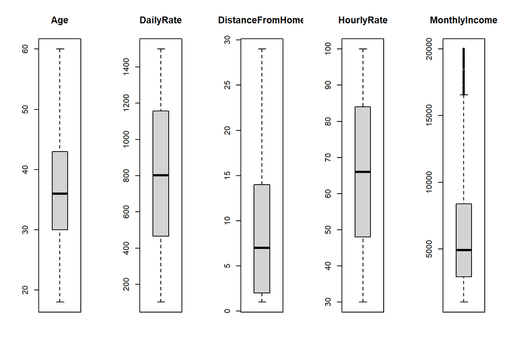

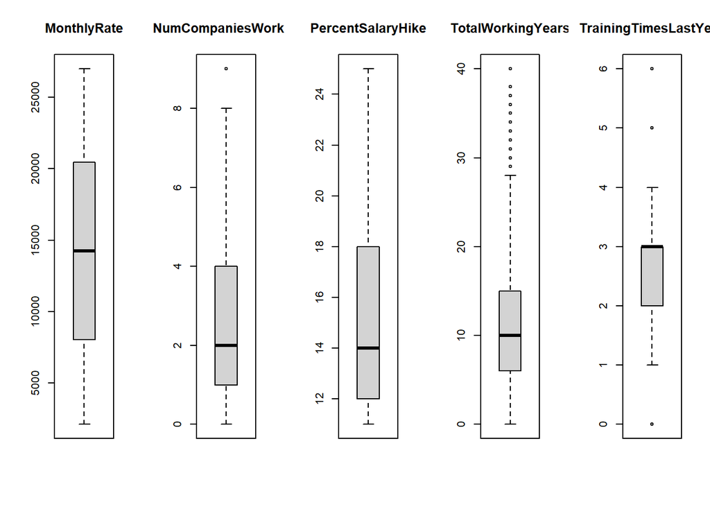

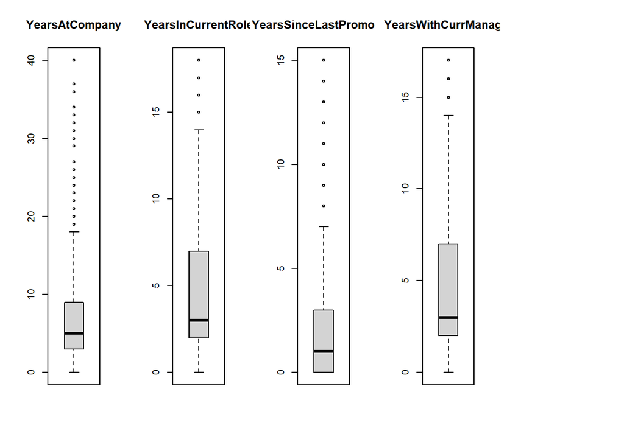

```r
# We create a vector with tha names of all the cuantitative variables that we already
# observed.
analysed_variables <- c("EmployeeCount", "StandardHours", "EmployeeNumber", ordinal_names)

# We save in a vector the indexes of this columns in the 'numeric_var' data frame
observed_indexes <- match(analysed_variables, names(numeric_var))

# We create other data frame which will not include these variables
not_observed_numeric <- numeric_var[-observed_indexes]

# We will visualize these variables using boxplots

# We will show them 5 by 5
par(mfrow = c(1, 5))
# We iterate over tha names of the columns
for (var in colnames(not_observed_numeric)) {
    # And create a boxplot for each variable
    boxplot(not_observed_numeric[[var]], main = var)
}
```

We can see multiple things. First, some of the boxplots are very similar to a normal distribution, as the median is right in the center of the figure, and the rest of the figure is symmetric above and below the median. On the other hand, many of these variables do not have univariate outliers. This could be positive since they won’t interfere with the models we train. However, there are also other boxplot that show some univariate outliers.

We will explore how many outliers are present in each variable.

```r
sapply(not_observed_numeric, function(x) length(boxplot.stats(x)$out))
```

```
##                     Age               DailyRate        DistanceFromHome              HourlyRate
##                       0                       0                       0                       0
##           MonthlyIncome             MonthlyRate      NumCompaniesWorked       PercentSalaryHike
##                     114                       0                      52                       0
##       TotalWorkingYears   TrainingTimesLastYear          YearsAtCompany      YearsInCurrentRole
##                      63                     238                     104                      21
## YearsSinceLastPromotion    YearsWithCurrManager
##                     107                      14
```

We observe that there are indeed variables without outliers. On the other hand, when outliers are present, they are quite few compared to the total number of observations (1470). Only one of the variables has more than 10% outliers (TrainingTimesLastYear).

On the other hand, in all the variables involving the temporal dimension (those that have ‘Year’ in their name), there are outliers, what raise suspicions that these outliers might be related to each other. We will display a correlation matrix of the quantitative variables to understand the relationships between the variables.

### 2.3.4 - Correlations between numeric continuous variables.

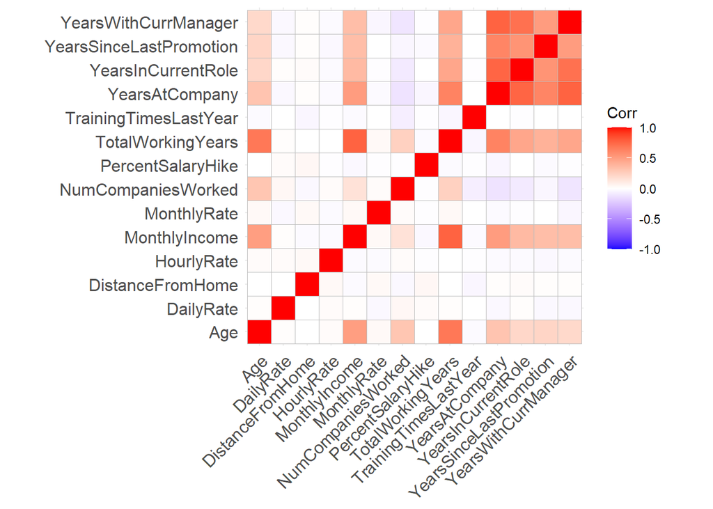

```r
# Import ggcorrplot
library(ggcorrplot)
# We create and visualize a correlation matrix with the numeric variables that we know
# that are quantitative
cor_numerics <- cor(not_observed_numeric)
ggcorrplot(cor_numerics)
```

All the variables that represent a temporal dimension are highly related to each other, which strengthens the previous idea that their outliers could be related. Additionally, there are other variables that correlate with the temporal ones, specifically age and monthly salary. The rest of the variables do not show any type of relationship. It is curious to note that the variable ‘TrainingTimesLastYear’ is not correlated with any variable, and it was the variable with the highest number of outliers.

### 2.3.5 - Multivariate outliers and their relation with univariates.

We will now perform a multivariate analysis of the outliers in the variables that we have observed to be related. If there exist multivariate outliers, we will also verify if are at the same time univariate outliers. This will help us to better understand the composition of those.

```r
# We save in a vector these variables
names_high_cor <- c("YearsWithCurrManager", "YearsSinceLastPromotion", "YearsInCurrentRole",
    "YearsAtCompany", "TotalWorkingYears", "Age")
# We select these variables
vars_high_cor <- HR_data[names_high_cor]
```

For studying multivariate outliers, we will use the mahalanobis_distance function from the rstatix package to mark all values that represent outliers according to this distance.

```r
library("rstatix")
vars_high_cor <- mahalanobis_distance(vars_high_cor)

# We eliminate the column that indicates the mahalanobis distance of each point to the
# center
vars_high_cor$mahal.dist <- NULL
# Now we will create a function that will replace each variable with a column where TRUE
# will indicate if for that variable the observation is a univariate outlier, and FALSE
# will indicate that is not
determine_univariate_outliers <- function(column) {

    # We get the values of the first and the third quartile
    Q1 <- quantile(column, 0.25, na.rm = TRUE)
    Q3 <- quantile(column, 0.75, na.rm = TRUE)
    # Using this values we calculate the interquartile range
    IQR <- Q3 - Q1
    # We create the limits of what is considered an outliers or not (Using the general
    # aproximation of +- 1.5IQR)
    bottom_limit <- Q1 - 1.5 * IQR
    top_limit <- Q3 + 1.5 * IQR

    # We determine which observation is an outlier, and generate a TRUE value when is it,
    # and a FALSE value when is not
    column <- column < bottom_limit | column > top_limit
    return(column)
}

# We will use this function for each column of the previous saved variables
for (name in names_high_cor) {
    vars_high_cor[[name]] <- determine_univariate_outliers(vars_high_cor[[name]])
}

# We visualize the aspect of this dataframe
head(vars_high_cor)
```

```
##   YearsWithCurrManager YearsSinceLastPromotion YearsInCurrentRole YearsAtCompany TotalWorkingYears   Age
## 1                FALSE                   FALSE              FALSE          FALSE             FALSE FALSE
## 2                FALSE                   FALSE              FALSE          FALSE             FALSE FALSE
## 3                FALSE                   FALSE              FALSE          FALSE             FALSE FALSE
## 4                FALSE                   FALSE              FALSE          FALSE             FALSE FALSE
## 5                FALSE                   FALSE              FALSE          FALSE             FALSE FALSE
## 6                FALSE                   FALSE              FALSE          FALSE             FALSE FALSE
##   is.outlier
## 1      FALSE
## 2      FALSE
## 3      FALSE
## 4      FALSE
## 5      FALSE
## 6      FALSE
```

After this process, we have obtained a dataframe where each observation is marked with a boolean value in each column. In the columns named as the variables, the boolean values indicates whether the observation is an outlier or not, and in the last column, the boolean indicates whether the observation is an outlier considering the entire dataset as a whole (multivariate outlier).

```r
# We show how many outliers there are in each column
colSums(vars_high_cor)
```

```
##    YearsWithCurrManager YearsSinceLastPromotion      YearsInCurrentRole          YearsAtCompany
##                      14                     107                      21                     104
##       TotalWorkingYears                     Age              is.outlier
##                      63                       0                      44
```

In some cases the number of univariate outliers is higher than the number of multivariate, and in others is smaller. Now we will verify what happens if we only observe the cases where the observations are mulitivariate outliers.

```r
colSums(vars_high_cor[vars_high_cor["is.outlier"] == TRUE, ])
```

```
##    YearsWithCurrManager YearsSinceLastPromotion      YearsInCurrentRole          YearsAtCompany
##                       7                      26                       5                      38
##       TotalWorkingYears                     Age              is.outlier
##                      26                       0                      44
```

In some variables, most of the multivariate outliers are at the same time univariate. However, in other cases, this is not happening (with the variable “YearsInCurrentRole”, only 5 observations are univariate outliers). So we can conclude that some of the outliers of these variables are related, but not most of them.

## 2.4 - Missing data.

Now we will verify how many missing values are in the dataset.

```r
sum(is.na(HR_data))
```

```
## [1] 0
```

```r
sum(HR_data == " ")
```

```
## [1] 0
```

We can see that there are not missing values in this dataset. This is something positive, because we will not generate biases using imputation methods.

# 3 - DATA CLEANING.

## 3.1 - Columns with only 1 unique value.

In the previously conducted EDA, we observed that multiple columns had the same and unique value. We will eliminate these columns.

```r
# We save in a vector the name of these variables
constants_names <- c("EmployeeCount", "StandardHours")
# We search the indexes of the columns with these names
indexes_to_eliminate <- match(constants_names, names(HR_data))
# We exclude the columns with these indexes from the complete dataset
HR_data <- HR_data[-indexes_to_eliminate]

# We will also discard the identifier of the employees, because is not necesary for the
# analysis
HR_data <- HR_data[-(match("EmployeeNumber", names(HR_data)))]
```

## 3.2 - Modifying some data types.

We are going to change the values of the binary variables from Yes/No to 1 or 0 (which will convert the variables to numeric).

```r
HR_data$Attrition <- ifelse(HR_data$Attrition == "No", 0, 1)
HR_data$OverTime <- ifelse(HR_data$OverTime == "No", 0, 1)
```

Now, we will convert the remaining character variables to factor type.

```r
# The levels of the variable 'BusinessTravel' can be sorted, we will make this conversion
# considering their levels
HR_data$BusinessTravel <- factor(HR_data$BusinessTravel, levels = c("Non-Travel", "Travel_Rarely",
    "Travel_Frequently"))

# Now we will convert the rest of the character variables We create a vector with their
# names
factor_var <- c("Department", "Gender", "MaritalStatus", "EducationField", "JobRole")

# And we make the conversion
HR_data[factor_var] <- lapply(HR_data[factor_var], as.factor)
```

## 3.3 - Codification of new variables.

Some of the variables we identified as ordinal are those ending in “Satisfaction”. We lack information about their actual range since the dataset download link didn’t provide the theoretical scale range. This means the variables might theoretically have values beyond those in this sample, making it difficult to interpret the values accurately. We can only rank the values without knowing their actual magnitude.

This approach helps to identify the most and least satisfied individuals by distinguishing them based on extreme values in the satisfaction metrics.

Next, we will create these variables:

```r
# High satisfaction
HR_data$High_satisfaction <- ifelse((HR_data$JobSatisfaction == max(HR_data$JobSatisfaction)) +
    (HR_data$EnvironmentSatisfaction == max(HR_data$EnvironmentSatisfaction)) + (HR_data$RelationshipSatisfaction ==
    max(HR_data$RelationshipSatisfaction)) >= 2, 1, 0)
# Low satisfaction
HR_data$Low_satisfaction <- ifelse((HR_data$JobSatisfaction == min(HR_data$JobSatisfaction)) +
    (HR_data$EnvironmentSatisfaction == min(HR_data$EnvironmentSatisfaction)) + (HR_data$RelationshipSatisfaction ==
    min(HR_data$RelationshipSatisfaction)) >= 2, 1, 0)

# We also transform other some numeric variables to factor, including those that we have
# just created (we use the same procedure as before, but with other variables. We do it
# separately for having more modularity in the transformation of both types of variables)
factor_var <- c("Attrition", "Education", "EnvironmentSatisfaction", "JobInvolvement", "JobSatisfaction",
    "OverTime", "PerformanceRating", "RelationshipSatisfaction", "StockOptionLevel", "WorkLifeBalance",
    "High_satisfaction", "Low_satisfaction")
HR_data[factor_var] <- lapply(HR_data[factor_var], as.factor)
```

## 3.4 - Outliers handling.

For handling them, we will make some tests, in order to find a good solution. We will make some transformations, and verify their effects.

```r
# We create a vector with the names of the variables that we identified in the previous
# section that have outliers.
vars_outliers <- c("MonthlyIncome", "NumCompaniesWorked", "TotalWorkingYears", "TrainingTimesLastYear",
    "YearsAtCompany", "YearsInCurrentRole", "YearsSinceLastPromotion", "YearsWithCurrManager")

# We create a version of these variables trasnformed using square root
for (name in vars_outliers) {

    # We will create a new name to which we add at the end of the iterated name,
    # '_scaled'. We use this name because we are going to standardize it later (the idea
    # is to first transform with the square root to reduce the effect of outliers, and
    # then standardize).
    name_scaled <- paste0(name, "_scaled")
    # We create a new variable, that contains the square root of the iterated variable
    # and has the new created name
    HR_data[[name_scaled]] <- sqrt(HR_data[[name]])
}
# After transforming the variable, we will verify how many outliers are in the variable
for (name in vars_outliers) {
    name_scaled <- paste0(name, "_scaled")
    print(name_scaled)
    print(length(boxplot.stats((HR_data[[name_scaled]]))$out))
}
```

```
## [1] "MonthlyIncome_scaled"
## [1] 0
## [1] "NumCompaniesWorked_scaled"
## [1] 0
## [1] "TotalWorkingYears_scaled"
## [1] 18
## [1] "TrainingTimesLastYear_scaled"
## [1] 238
## [1] "YearsAtCompany_scaled"
## [1] 29
## [1] "YearsInCurrentRole_scaled"
## [1] 0
## [1] "YearsSinceLastPromotion_scaled"
## [1] 0
## [1] "YearsWithCurrManager_scaled"
## [1] 0
```

Now only 3 variables still have outliers. Moreover, in 2 of these, the number of outliers is lower than it was before, indicating that the transformation reduces the number of outliers or eliminates them completely. The last step is to check how far the remaining outliers are from the center of the data in terms of standard deviations, compared to the original variables.

```r
# We create a vector in which we store the names of the variables transformed using the
# square root where still remain outliers.
still_outliers <- c("TotalWorkingYears", "TrainingTimesLastYear", "YearsAtCompany")


# We create a function that calculates the distance in standard deviations from the
# highest outlier and the mean
distancia_outliers <- function(column) {
    # We will create the name of the transformed variables adding '_scaled' at the end
    scaled_name <- paste0(column, "_scaled")

    # We get the mean and the standart deviation of the original variablo and the
    # transformed
    sd_normal <- sd(HR_data[[column]])
    mean_normal <- mean(HR_data[[column]])
    sd_scaled <- sd(HR_data[[scaled_name]])
    mean_scaled <- mean(HR_data[[scaled_name]])

    # We get the outliers from the original variable and the transformed one
    outliers_normal <- boxplot.stats(HR_data[[column]])$out
    outliers_scaled <- boxplot.stats(HR_data[[scaled_name]])$out

    # We calculate the distance in standard deviations for the outlier with the highest
    # value in the original variable
    print(column)
    print(max((outliers_normal - mean_normal)/sd_normal))

    # We repeat the process with the transformed variable
    print(scaled_name)
    print(max((outliers_scaled - mean_scaled)/sd_scaled))
}

# We use this function with all the variables where remain outliers after transforming
# them
for (column in still_outliers) {
    distancia_outliers(column)
}
```

```
## [1] "TotalWorkingYears"
## [1] 3.691198
## [1] "TotalWorkingYears_scaled"
## [1] 2.734748
## [1] "TrainingTimesLastYear"
## [1] 2.482551
## [1] "TrainingTimesLastYear_scaled"
## [1] 1.840419
## [1] "YearsAtCompany"
## [1] 5.385081
## [1] "YearsAtCompany_scaled"
## [1] 3.538725
```

In all cases, in terms of standard deviations, the maximum distance of the highest outlier from the mean has decreased. Therefore, the transformation in these cases also has the desired effect, reducing the extremity of the outliers.

## 3.5 - Standardization of variables.

Now we will standardize the quantitative variables of this dataset using the “min-max scaller” technique.

```r
# For this task we will use a function The function has as input a column We get the
# maximum and the minimum of the column
minmax_scaling <- function(column) {
    min_val <- min(column)
    max_val <- max(column)
    # We apply the min-max scaller formula to the column
    scaled_column <- (column - min_val)/(max_val - min_val)
    return(scaled_column)
}  # We return the column standarized

# We create a vector with the names of the remaining variables that we also want to
# standardize.
rest_scalling_vars <- c("Age", "DailyRate", "DistanceFromHome", "HourlyRate", "MonthlyRate",
    "PercentSalaryHike")

# We standardize the variables to which we have applied the square root.
for (name in paste0(vars_outliers, "_scaled")) {
    HR_data[[name]] <- minmax_scaling(HR_data[[name]])
}

# We create new standardized variables with the remaining quantitative variables (the
# ones we did not transformed using the square root).
for (name in rest_scalling_vars) {
    name_scaled <- paste0(name, "_scaled")
    HR_data[[name_scaled]] <- minmax_scaling(HR_data[[name]])
}
```

## 3.6 - Discretizing variables.

We will also create a discretized version of each of these variables that we have standardized. This way, the final dataset will contain multiple versions of the variables, providing more options when testing which variable selection and formats work best for building a model that functions correctly for our purposes. This will allow us to see which variables and formats work best for the model we ultimately choose. We will use ‘k-means’ to create the intervals, as this method automatically adjusts the intervals for each partition, ensuring that the number of observations within each interval is similar.

```r
# We will use the package 'arules'
library(arules)
# We will create a vector with the names of all the standardized variables. First, we
# will store in it the names of the variables with outliers, and then the names of those
# without outliers (we have these names in another vector). We will add '_scaled' at the
# end of the name of the variables to do the discretization with the standarized
# variables.

scaled_vars <- paste0(vars_outliers, "_scaled")
scaled_vars <- c(scaled_vars, paste0(rest_scalling_vars, "_scaled"))
# We check all the values in this vector for ensuring that everything is correct
scaled_vars
```

```
##  [1] "MonthlyIncome_scaled"           "NumCompaniesWorked_scaled"      "TotalWorkingYears_scaled"
##  [4] "TrainingTimesLastYear_scaled"   "YearsAtCompany_scaled"          "YearsInCurrentRole_scaled"
##  [7] "YearsSinceLastPromotion_scaled" "YearsWithCurrManager_scaled"    "Age_scaled"
## [10] "DailyRate_scaled"               "DistanceFromHome_scaled"        "HourlyRate_scaled"
## [13] "MonthlyRate_scaled"             "PercentSalaryHike_scaled"
```

```r
# We iterate over these names
for (name in scaled_vars) {
    # We create a new name for the discretized variable by replacing '_scaled' with
    # '_discret'
    disc_name <- gsub("_scaled", "_discret", name)
    # We create a new variable with the discretized data using k-means, with 4 intervals
    HR_data[[disc_name]] <- discretize(HR_data[[name]], method = "cluster", breaks = 4)
}
# We check the first values of these variables
head(HR_data[35:62])
```

```
##   MonthlyIncome_scaled NumCompaniesWorked_scaled TotalWorkingYears_scaled TrainingTimesLastYear_scaled
## 1            0.4163104                 0.9428090                0.4472136                    0.0000000
## 2            0.3635034                 0.3333333                0.5000000                    0.7071068
## 3            0.1272355                 0.8164966                0.4183300                    0.7071068
## 4            0.2021867                 0.3333333                0.4472136                    0.7071068
## 5            0.2473708                 1.0000000                0.3872983                    0.7071068
## 6            0.2154502                 0.0000000                0.4472136                    0.5773503
##   YearsAtCompany_scaled YearsInCurrentRole_scaled YearsSinceLastPromotion_scaled YearsWithCurrManager_scaled
## 1             0.3872983                 0.4714045                      0.0000000                   0.5423261
## 2             0.5000000                 0.6236096                      0.2581989                   0.6416889
## 3             0.0000000                 0.0000000                      0.0000000                   0.0000000
## 4             0.4472136                 0.6236096                      0.4472136                   0.0000000
## 5             0.2236068                 0.3333333                      0.3651484                   0.3429972
## 6             0.4183300                 0.6236096                      0.4472136                   0.5940885
##   Age_scaled DailyRate_scaled DistanceFromHome_scaled HourlyRate_scaled MonthlyRate_scaled
```

[output cut: 34 more lines]

We can see that the values are numbers with many decimal places. However, in several variables, some of these values repeat because they represent the boundaries of the intervals used for discretization.

# 4 - SINGULAR VALUES DECOMPOSITION.

After finishing with the EDA and cleaning and manipulating the data, we will explore the dimentionality of the data. In this case we will use the tecnique “Singular values decomposition”.

```r
# We will perform the decomposition using the standardized versions of the variables.
# First, we create a dataframe for this purpose
X <- HR_data[scaled_vars]

# We convert this dataframe to a matrix
X <- as.matrix(X)

# We perform a singular value decomposition of this matrix using the 'svd' function
x_svd <- svd(X)
```

The object obtained by applying ‘svd’ internally contains 3 elements. Specifically, these elements correspond to the results of performing singular value decomposition. They are as follows: “u”, “d”, and “v”, which hold the information found in the matrices U, S, and V of the singular value decomposition formula:

A=UxSxV^t

where A is the original data matrix, “U” and “V” are the matrices of right and left singular vectors, and S is the singular matrix, where its diagonal contains the singular values. By multiplying these last 3 matrices as shown in the formula, we would obtain the original data.

In “d” we have the elements that would be on the diagonal of the matrix S, that is, the singular values. These values indicate the relative importance of each column in the matrices U and V, and thus in the data. We will graphically display their values.”

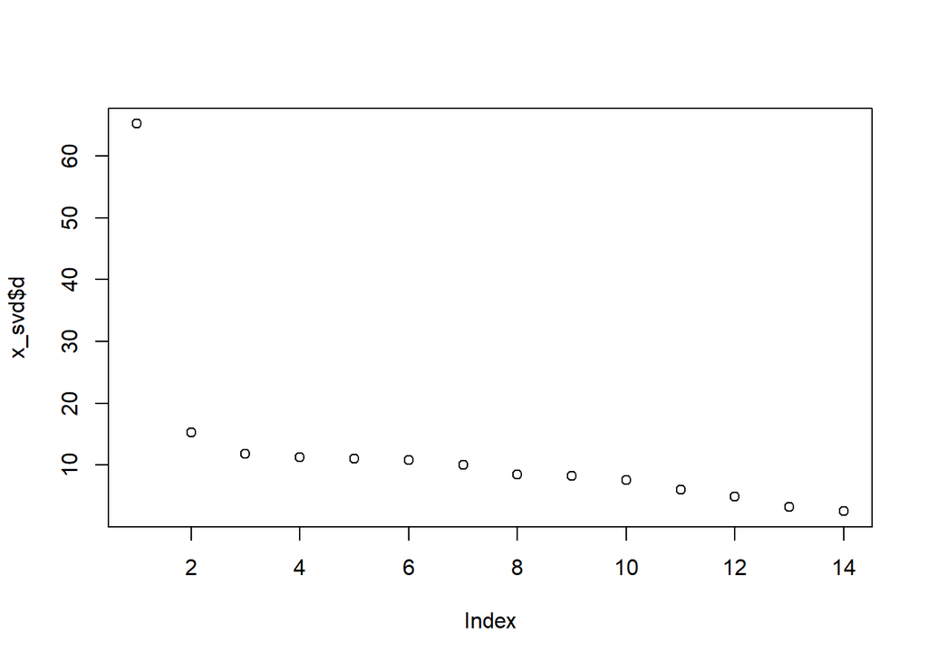

```r
plot(x_svd$d)
```

We see that the first singular value is the most important, with a significant difference compared to the others. The remaining singular values progressively decrease in magnitude.

By squaring these values and expressing them as a proportion of the total, we can determine the percentage of variance in the original data explained by each singular value multiplied by its corresponding right and left singular vectors.

```r
prop.table(x_svd$d^2)
```

```
##  [1] 0.792658534 0.043357381 0.026183538 0.023775304 0.022497084 0.021906527 0.018805973 0.013255432
##  [9] 0.012688123 0.010612725 0.006665778 0.004478507 0.001930596 0.001184499
```

We see that using only the first column of “u”, “v”, and the first value of “d”, we can explain almost 80% of the variance in the data. Therefore, with a significantly smaller amount of information, we can represent most of the variance in the original data.

The resources consulted for this section are as follows:

- First: https://rpubs.com/reyzaguirre/460513
- Second: https://rpubs.com/skydome20/92492
- Third: documentation of the function “svd”
- Forth: https://www.displayr.com/singular-value-decomposition-in-r/#:~:text=This%20post%20is%20going%20to,tutorial%20and%20discuss%20SVD%20properties

# 5 - USING A NON SUPERVISED METHOD (HIERARCHICAL CLUSTERING).

We will use an unsupervised method of **Hierarchical Clustering**, specifically an agglomerative hierarchical clustering method. For this, the following guide (is a guide in Spanish) has been consulted:

https://rpubs.com/mjimcua/clustering-jerarquico-en-r

Previously, the dataset was prepared with both discrete and normalized versions of the quantitative variables using min-max scaling. However, the results from the model built with these normalized variables are not satisfactory. As a result, two models will be developed in parallel: one using min-max normalization and the other using standardization (mean of 0 and standard deviation of 1). This comparison will help assess the impact of different scaling methods on the model’s performance.

Qualitative variables will be excluded as this model require cuantitative variables. Since we are using fewer variables than available in the dataset, we will just explore if the observations naturally group into distinct clusters or if further refinement in variable selection is needed to achieve clearer groupings.

We start preparing the datasets:

```r
# We create a dataset which only contains the normalized variables. We will select them
# by their indexes (I verifyed them manually)
dat_norm <- data.frame(HR_data[35:48])
# We show the first columns
head(dat_norm)
```

```
##   MonthlyIncome_scaled NumCompaniesWorked_scaled TotalWorkingYears_scaled TrainingTimesLastYear_scaled
## 1            0.4163104                 0.9428090                0.4472136                    0.0000000
## 2            0.3635034                 0.3333333                0.5000000                    0.7071068
## 3            0.1272355                 0.8164966                0.4183300                    0.7071068
## 4            0.2021867                 0.3333333                0.4472136                    0.7071068
## 5            0.2473708                 1.0000000                0.3872983                    0.7071068
## 6            0.2154502                 0.0000000                0.4472136                    0.5773503
##   YearsAtCompany_scaled YearsInCurrentRole_scaled YearsSinceLastPromotion_scaled YearsWithCurrManager_scaled
## 1             0.3872983                 0.4714045                      0.0000000                   0.5423261
## 2             0.5000000                 0.6236096                      0.2581989                   0.6416889
## 3             0.0000000                 0.0000000                      0.0000000                   0.0000000
## 4             0.4472136                 0.6236096                      0.4472136                   0.0000000
## 5             0.2236068                 0.3333333                      0.3651484                   0.3429972
## 6             0.4183300                 0.6236096                      0.4472136                   0.5940885
##   Age_scaled DailyRate_scaled DistanceFromHome_scaled HourlyRate_scaled MonthlyRate_scaled
## 1  0.5476190        0.7158196              0.00000000         0.9142857         0.69805260
## 2  0.7380952        0.1267001              0.25000000         0.4428571         0.91600080
## 3  0.4523810        0.9098067              0.03571429         0.8857143         0.01212608
## 4  0.3571429        0.9234073              0.07142857         0.3714286         0.84581409
## 5  0.2142857        0.3500358              0.03571429         0.1428571         0.58373821
## 6  0.3333333        0.6463851              0.03571429         0.7000000         0.39229070
##   PercentSalaryHike_scaled
## 1               0.00000000
## 2               0.85714286
## 3               0.28571429
## 4               0.00000000
## 5               0.07142857
## 6               0.14285714
```

```r
# We also select the variables in their original verison. We will select the indexes for
# ensuring the same order as in the original dataset (I verifyed them manually)
dat_est <- HR_data[c(17, 19, 26, 27, 29, 30, 31, 32, 1, 4, 6, 11, 18, 22)]
# We standarize these variables
dat_est <- data.frame(scale(dat_est))
# We show the first columns
head(dat_est)
```

```
##   MonthlyIncome NumCompaniesWorked TotalWorkingYears TrainingTimesLastYear YearsAtCompany YearsInCurrentRole
## 1    -0.1083127          2.1244130        -0.4214990            -2.1712429   -0.164557109        -0.06327437
## 2    -0.2916193         -0.6778187        -0.1644554             0.1556541    0.488341541         0.76473737
## 3    -0.9373347          1.3237753        -0.5500208             0.1556541   -1.143905083        -1.16729002
## 4    -0.7633739         -0.6778187        -0.4214990             0.1556541    0.161892216         0.76473737
## 5    -0.6446387          2.5247318        -0.6785426             0.1556541   -0.817455758        -0.61528219
## 6    -0.7296013         -1.0781375        -0.4214990            -0.6199782   -0.001332446         0.76473737
##   YearsSinceLastPromotion YearsWithCurrManager         Age  DailyRate DistanceFromHome HourlyRate MonthlyRate
## 1             -0.67891464            0.2457504  0.44619856  0.7422739       -1.0105654  1.3826677   0.7257730
## 2             -0.36858985            0.8062671  1.32191535 -1.2973331       -0.1470997 -0.2405949   1.4883696
## 3             -0.67891464           -1.1555415  0.00834016  1.4138821       -0.8872132  1.2842882  -1.6742711
## 4              0.25205973           -1.1555415 -0.42951824  1.4609690       -0.7638609 -0.4865438   1.2427877
## 5             -0.05826506           -0.5950247 -1.08630583 -0.5241163       -0.8872132 -1.2735802   0.3257890
## 6              0.25205973            0.5260087 -0.53898284  0.5018828       -0.8872132  0.6448211  -0.3440822
##   PercentSalaryHike
## 1       -1.15016269
## 2        2.12858163
## 3       -0.05724792
## 4       -1.15016269
## 5       -0.87693400
## 6       -0.60370530
```

## 5.1 - Model creation.

Now we begin to create the model. Since we are going to create 2 models in parallel, each of the commands used will be repeated twice to store the result with each measurement scale used.

```r
par(mfrow = c(1, 2))
# We need the library 'cluster'
library(cluster)

# We calculate the dissimilarities matrix
d_norm_euc <- dist(dat_norm, method = "euclidean")
d_est_euc <- dist(dat_est, method = "euclidean")

# We create a hierarchical clustering models with each of these distances
hc_norm_euc <- hclust(d_norm_euc, method = "complete")
hc_est_euc <- hclust(d_est_euc, method = "complete")
```

Now we will show the resulting dendrogram from creating this model. Since these dendrograms have many labels, and there’s no way for them to be legible (they overlap), I have decided to make the labels on the X-axis very small, and we will focus more on the shape of the obtained clusters.

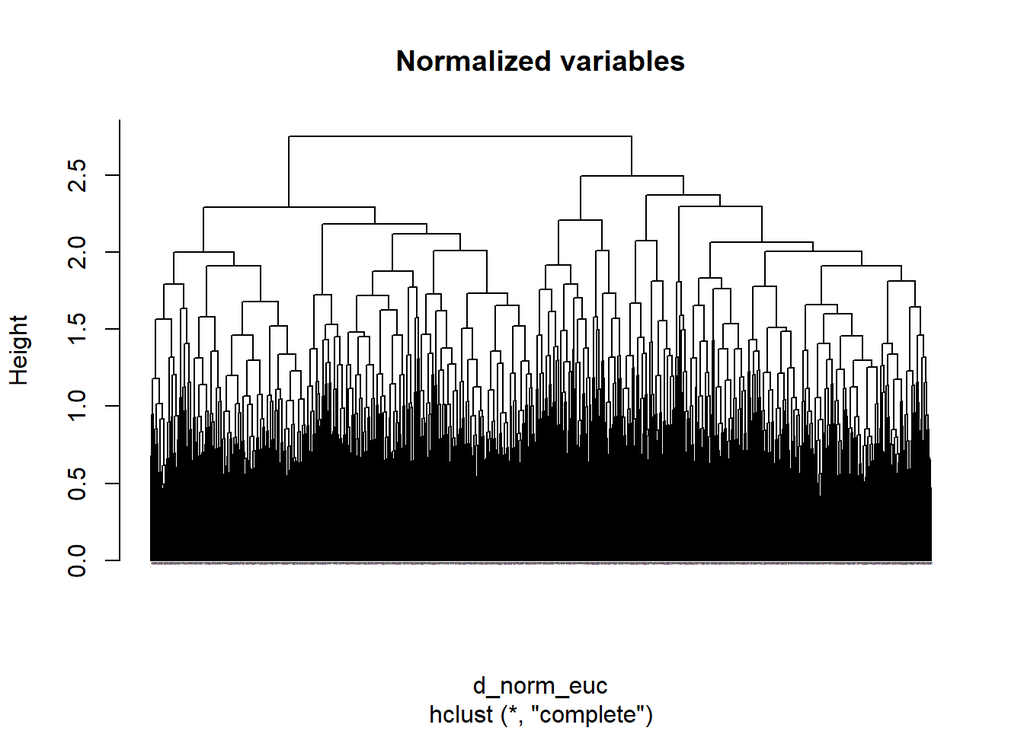

```r
plot(hc_norm_euc, cex = 0.01, hang = -1, main = "Normalized variables")
```

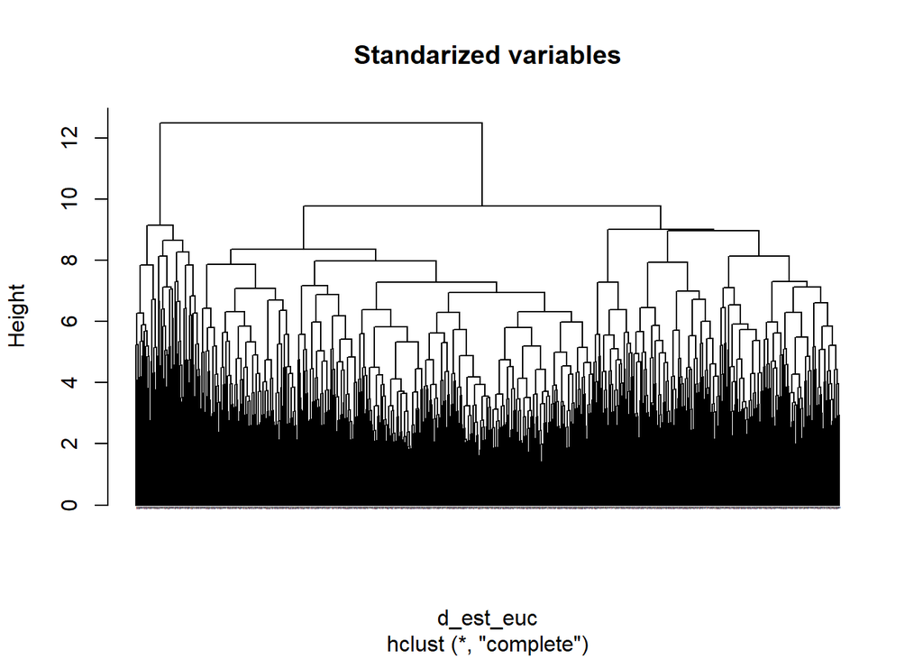

```r
plot(hc_est_euc, cex = 0.01, hang = -1, main = "Standarized variables")
```

There are many branches in both cases, but their shapes change depending on the scale of the variables. We didn’t set the number of clusters, as this depends on where we cut the tree. This will determine the number of branches. Each cut branch will be a different cluster.

In the next step, we will determine the number of clusters that yield the best result.

## 5.2 - Analysis of the results of the model.

We will create a function that returns a vector with the medium silhouette of the model, with different number of clusters (the function will test multiple number of clusters in each model and get the medium silhouette for each case)

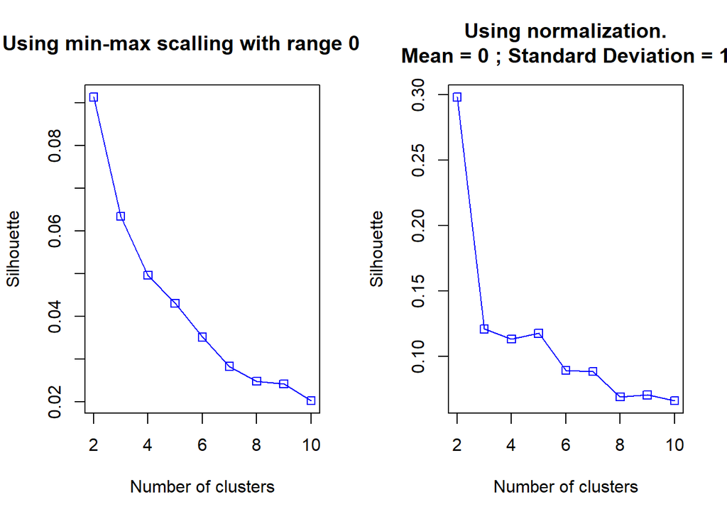

```r
calculate_silhouettes <- function(model, distances) {
    # We create a vector with 10 zeros that we will replace with the silhouette values
    results <- rep(0, 10)

    # We iterate from 2 to 10
    for (i in 2:10) {
        # In each iteration we will cut the dendrogram for getting 'i' clusters
        y_cluster <- cutree(model, k = i)
        # We calculate the medium silhouette of the clusters obtaine with this cut of the
        # dendrogram
        sk <- silhouette(y_cluster, distances)
        results[i] <- mean(sk[, 3])
    }

    # Return the results
    return(results)
}

# We call this function with both models previously created and both dissimilarities
# matrixes calculated
results_1 <- calculate_silhouettes(hc_norm_euc, d_norm_euc)
results_2 <- calculate_silhouettes(hc_est_euc, d_est_euc)

# We show graphically the medium silhouette for each model and each number of clusters
par(mfrow = c(1, 2))
plot(2:10, results_1[2:10], type = "o", col = "blue", pch = 0, xlab = "Number of clusters",
    ylab = "Silhouette", main = "Using min-max scalling with range 0 to 1")
plot(2:10, results_2[2:10], type = "o", col = "blue", pch = 0, xlab = "Number of clusters",
    ylab = "Silhouette", main = "Using normalization.
Mean = 0 ; Standard Deviation = 1")
```

The highest average silhouette score is obtained with 2 clusters using both scaling methods. However, when using standardized distances, the result is much better (the Y-axis values in this second case are higher).

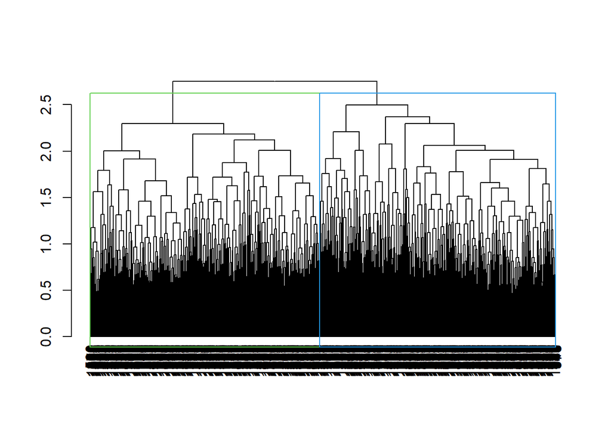

```r
plot(as.dendrogram(hc_norm_euc))
rect.hclust(hc_norm_euc, k = 2, border = 3:4)
```

## 5.3 - Conclusions.

Depending on the scale of the variables, the effectiveness of the model changes. Although with both scales the number of clusters with the highest average silhouette is 2, when we standardize the data, the average silhouette is higher than when we normalize it. For this reason, the best model is the 2-cluster model obtained with standardized data. However, the maximum average silhouette obtained is 0.3. Thus, the model does not seem to be producing very solid clusters.

It is also important to consider that since we are only using quantitative variables (as distance-based models cannot use categorical variables), we might be missing information that could be very important for differentiating groups in the data. However, this is a characteristic of the model; since it operates based on distances, there is nothing we can do to address this problem.

# 6 - USING DBSCAN AND OPTICS.

## 6.1 - Creating the model.

```r
library(dbscan)
# We train OPTICS algorithm using the default value of eps and the 2 mentioned values of
# minPts
optics_100 <- optics(dat_est, minPts = 100)
optics_400 <- optics(dat_est, minPts = 400)
```

To train the DBSCAN algorithm, I iteratively adjusted the “eps_cl” values before choosing the ones that will be shown in the code below. I selected values that allow for easy visualization of the behavior of both models.

```r
# We extract the agrupation using: eps_cl = 2
dbscan100_2 <- extractDBSCAN(optics_100, eps_cl = 2)
dbscan400_2 <- extractDBSCAN(optics_400, eps_cl = 2)
# We extract the agrupation using: eps_cl = 2.5
dbscan100_2_5 <- extractDBSCAN(optics_100, eps_cl = 2.5)
dbscan400_2_5 <- extractDBSCAN(optics_400, eps_cl = 2.5)
# We extract the agrupation using: eps_cl = 3
dbscan100_3 <- extractDBSCAN(optics_100, eps_cl = 3)
dbscan400_3 <- extractDBSCAN(optics_400, eps_cl = 3)
# We extract the agrupation using: eps_cl = 3.5
dbscan100_3_5 <- extractDBSCAN(optics_100, eps_cl = 3.5)
dbscan400_3_5 <- extractDBSCAN(optics_400, eps_cl = 3.5)
```

Now, for inspecting the results we just need to access the objects we saved and display their results.

## 6.2 - Inspecting the results.

```r
# We show the results of boths models trained with OPTICS
optics_100
```

```
## OPTICS ordering/clustering for 1470 objects.
## Parameters: minPts = 100, eps = 7.32728910557963, eps_cl = NA, xi = NA
## Available fields: order, reachdist, coredist, predecessor, minPts, eps, eps_cl, xi
```

```r
optics_400
```

```
## OPTICS ordering/clustering for 1470 objects.
## Parameters: minPts = 400, eps = 8.89343112855729, eps_cl = NA, xi = NA
## Available fields: order, reachdist, coredist, predecessor, minPts, eps, eps_cl, xi
```

With a significant increase in the neighborhood criterion (minPts), the value of “eps” has increased only slightly. In the first model, it is 7.327, and in the second model, it is 8.8934. This means that to find 4 times more points, the search radius only needs to increase slightly.

Now we show graphically the results of these 2 models:

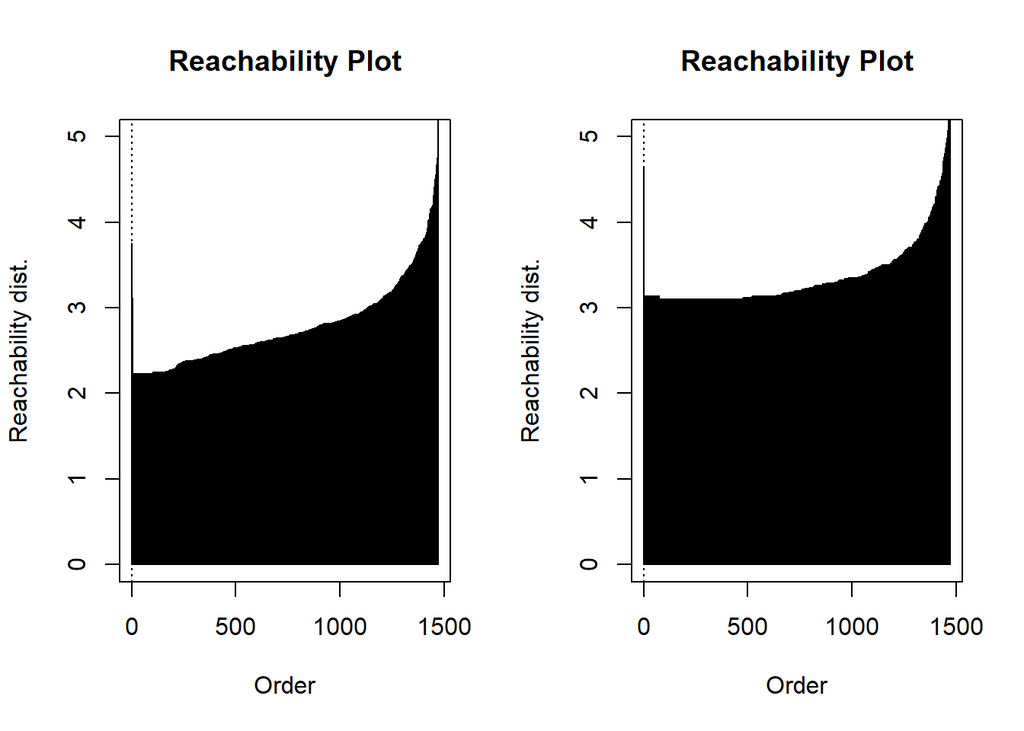

```r
par(mfrow = c(1, 2))
plot(optics_100, ylim = c(0, 5))
plot(optics_400, ylim = c(0, 5))
```

The difference between both results is not very big. The unique difference is that in the first model, the distance for each observation increases in a more progressive way than in the second model. However, the distances on both models are big.

**eps_cl = 2**

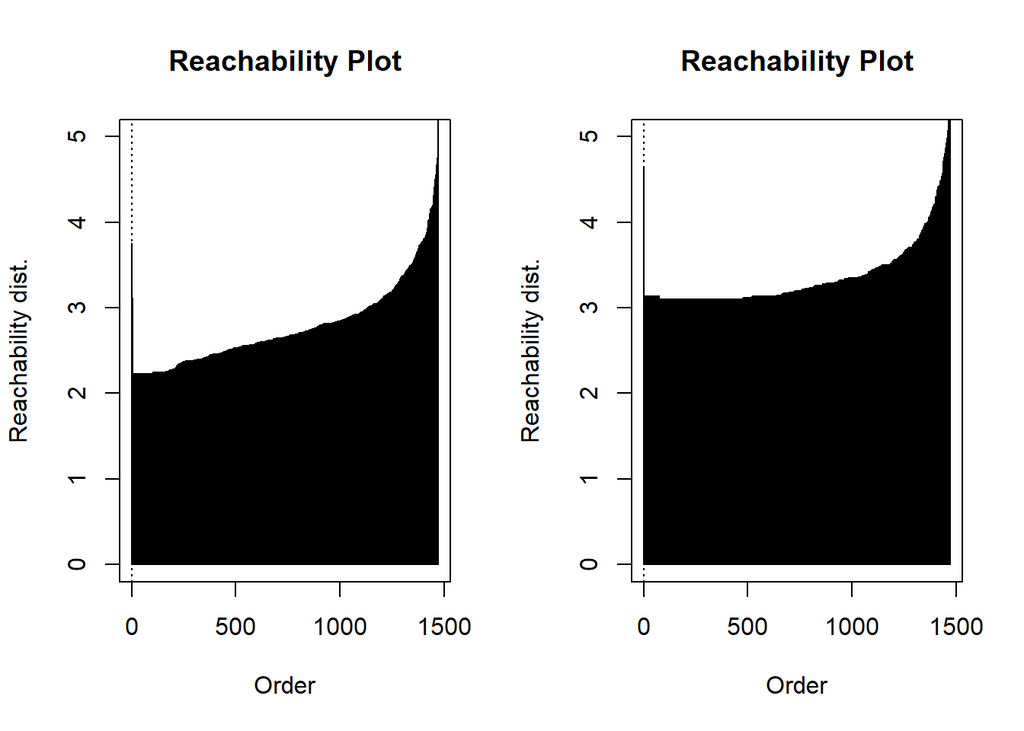

```r
par(mfrow = c(1, 2))
plot(dbscan100_2, ylim = c(0, 5))
plot(dbscan400_2, ylim = c(0, 5))
```

Initially, no clusters are detected in either of the models.

**eps_cl = 2,5**

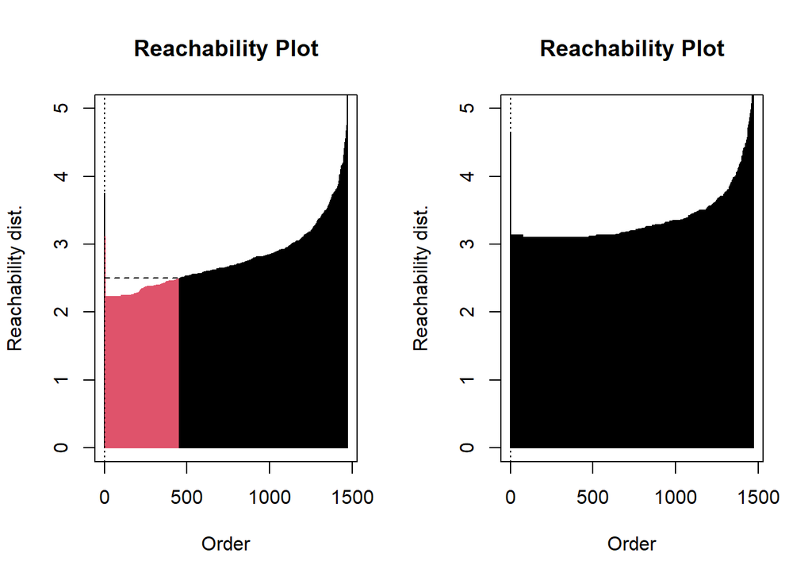

```r
par(mfrow = c(1, 2))
plot(dbscan100_2_5, ylim = c(0, 5))
plot(dbscan400_2_5, ylim = c(0, 5))
```

A cluster appears in the first model, but in the second everything is still noise. This outcome is logicical, given that in the first optics model, the initial reachability distances are shorter than in the second optics model.

**eps_cl = 3**

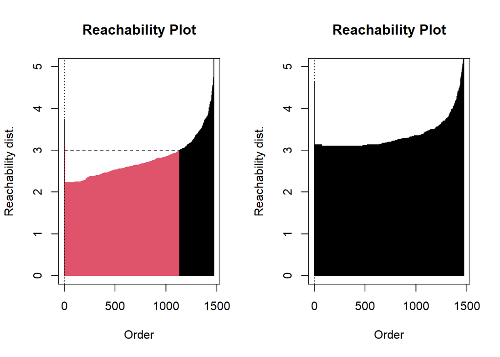

```r
par(mfrow = c(1, 2))
plot(dbscan100_3, ylim = c(0, 5))
plot(dbscan400_3, ylim = c(0, 5))
```

The size of the cluster in the first model has increased, and in the second model everything is still noise.

**eps_cl = 3.5**

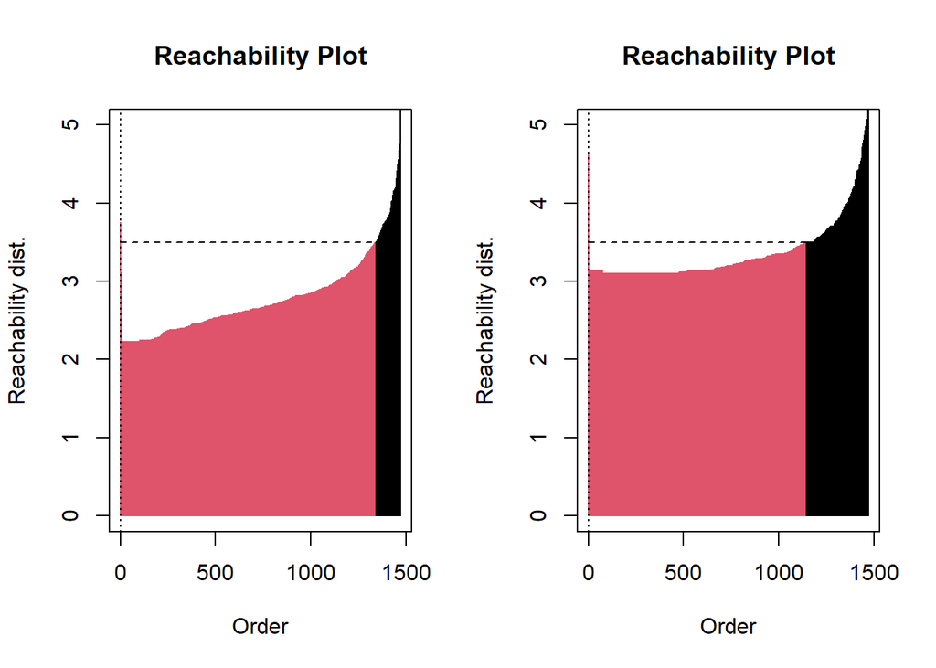

```r
par(mfrow = c(1, 2))
plot(dbscan100_3_5, ylim = c(0, 5))
plot(dbscan400_3_5, ylim = c(0, 5))
```

The cluster in the first model has grown even more and now occupies almost all the observations. In the second model, a cluster of nearly the same size as the cluster in the first model has abruptly appeared.

The results reveal interesting patterns. With a relatively low minPts value (100), a cluster gradually forms as the eps_cl parameter increases. On the other hand, when minPts is increased to 400, only noise is initially identified, reflecting significant rigidity in neighborhood definition due to the high density required to form a cluster. However, when eps_cl is raised to 3.5, a clustering pattern similar to that of the model with a lower minPts value emerges. This suggests that the data possess an underlying dense structure that only becomes evident under broader distance thresholds.

## 6.3 - Getting a measure of the quality of the clustering.

First, we will examine the appearance of these 2 clusters representing them with 2 principal components. We will to this visualization with the 2 last models.

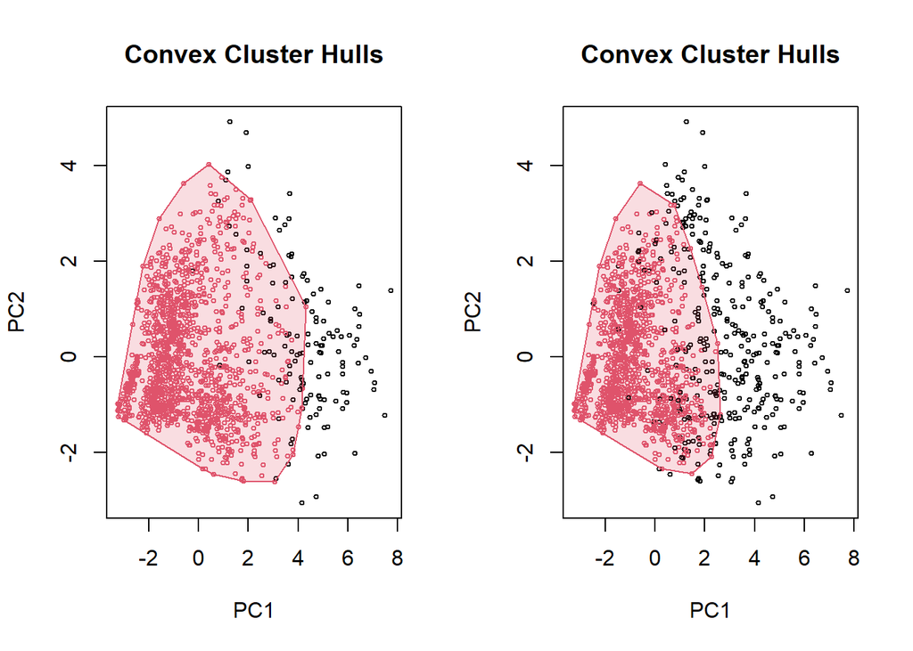

```r
par(mfrow = c(1, 2))
hullplot(dat_est, dbscan100_3_5)
hullplot(dat_est, dbscan400_3_5)
```

In both models there is only a single cluster of points, with some points gradually moving away from this structure. Both models capture a large portion of the points with the highest density and exclude most of the points with lower density. Therefore, it seems logical that the model does not find more than a single cluster.

```r
# We extract the data which is part of the cluster
cluster_data <- dat_est[dbscan400_3_5$cluster == 1, ]

# Whe also extract the data which is not part of the cluster
non_cluster_data <- dat_est[dbscan100_3_5$cluster == 0, ]

# We calculate the centroid of the principal cluster (the mean value of the values of the
# cluster)
centroid_cluster <- colMeans(cluster_data)

# We calculate the squared summatory of the points of the cluster
ssw_cluster <- sum(rowSums((cluster_data - centroid_cluster)^2))
# And we get the average value of this sum
average_ssw_cluster <- ssw_cluster/nrow(cluster_data)

# And now we get the sum of squares of the points out of the cluster (from the points to
# the calculated centroid)
ssw_non_cluster <- sum(rowSums((non_cluster_data - centroid_cluster)^2))
# We get the average value of this sum
average_ssw_non_cluster <- ssw_non_cluster/nrow(non_cluster_data)


# We show both average values
print(paste0("Sum of Squares Within inside the cluster: ", average_ssw_cluster))
```

```
## [1] "Sum of Squares Within inside the cluster: 10.5687405280119"
```

```r
print(paste0("Sum of Squares Within outside the cluster: ", average_ssw_non_cluster))
```

```
## [1] "Sum of Squares Within outside the cluster: 40.3439186176013"
```

The mean value of the sum of squared distances to the centroid differs significantly between the points inside the cluster and those outside it. Therefore, it is clear that the cluster identified by the model is dense. However, is not clear if with this data using a method like this is more useful than applying an outlier detection method.

# 7 - DECISION TREE MODEL.

## 7.1 - Train test split.

**A last data manipulation**

This project is a migration of other project. When initially I did this code, I forgot to delete the variable “Over18” until this point of the project. If I delete before in the script, some parts stop working because refactoring is needed. For now, this variable will be eliminated in this point of the project. The most adequate solution will be to delete it in the part of the script where all de variable elimination are done and refactor the code. But for now, we keep this solution, because is not a serious problem.

```r
# We delete the variable 'Over18'
name <- "Over18"
index <- match(name, names(HR_data))
HR_data <- HR_data[-index]



# TO DO

# THIS VARIABLE SHOULD BE ELMINATED IN THE SECTION WHERE ALL THE ELIMINATIONS ARE MADE,
# AND REFACTOR THE CODE. ALSO IS REQUIERED DELETING THIS CODE AFTER REFACTORING
```

**Continuation with the project**

Before starting with train test split, we will select only the variables most appropiate variables for building the model. We will consider 2 things; first, we will not select more than one version of the the same variable, and second, we will choose only the most important/relevant ones for building our model.

The discrete/standardized versions of some variables that we previouslty created are at the end of the dataset, from variable 34 onwards. Therefore, we will only select the first 33 to build the model. Since a rule-based model requires understanding the meaning of the variables, we will choose the original variables, to improve the interpretability of the model.

```r
# We select all the original variables.
split_dat <- HR_data[1:33]
# Previously we also created some new variables, based on the value of others. For
# creating the decision tree we will only use the new variables, so we will discard the
# variables used for creating them.

# We save in a vector their names
discard_vars <- c("JobSatisfaction", "EnvironmentSatisfaction", "RelationshipSatisfaction")
# We discard these variables
indexes_eliminate <- match(discard_vars, colnames(split_dat))
split_dat <- split_dat[-indexes_eliminate]
# Mostramos cuantas columnas nos quedan en el dataset
ncol(split_dat)
```

```
## [1] 30
```

We still have a lot of variables. We will select only the most important ones, because having too many variables increases the risk of including irrelevant variables in the training, which can also have an impact on the predictions.

```r
# We load the required packages for doing the study of the importance of the variables
library(RWekajars)
library(RWeka)
library(FSelector)

# We create a dataframe to store the results of the evaluation of each variable's
# importance
results_df <- data.frame()

# First we iterate over each column of the dataset
for (var in colnames(split_dat[-2])) {
    # We create a formula which includes the variable 'Attrition' and the iterated
    # variable, that will have to format 'Attrition ~ var'
    formula <- as.formula(paste("Attrition ~", var))
    # We store in a variable the information gain of each iterated variable
    info_gain <- information.gain(formula, split_dat)
    # We add the result to the dataframe with the results
    results_df <- rbind(results_df, info_gain)
}


# Now we sho the final datarame sorting the rows by the values of the column created for
# measuring the importance of the variable
results_df <- data.frame(results_df[order(results_df$attr_importance), , drop = FALSE])
results_df
```

```
##                         attr_importance
## DailyRate                  0.000000e+00
## DistanceFromHome           0.000000e+00
## HourlyRate                 0.000000e+00
## MonthlyRate                0.000000e+00
## NumCompaniesWorked         0.000000e+00
## PercentSalaryHike          0.000000e+00
## TrainingTimesLastYear      0.000000e+00
## YearsSinceLastPromotion    0.000000e+00
## PerformanceRating          4.158349e-06
## Gender                     4.372823e-04
## Education                  1.088435e-03
## High_satisfaction          1.641157e-03
## Department                 3.568144e-03
## WorkLifeBalance            4.786845e-03
## EducationField             5.068077e-03
## Low_satisfaction           6.118896e-03
## BusinessTravel             8.081713e-03
## JobInvolvement             8.732048e-03
## YearsInCurrentRole         1.307347e-02
## MaritalStatus              1.496588e-02
## Age                        1.646181e-02
## YearsWithCurrManager       1.826648e-02
## YearsAtCompany             1.885243e-02
## TotalWorkingYears          2.019828e-02
## MonthlyIncome              2.076296e-02
## StockOptionLevel           2.098402e-02
## JobLevel                   2.179277e-02
## OverTime                   2.768761e-02
## JobRole                    3.024106e-02
```

Some variables have very low importance. We will use a threshold of 0.005 for using a variable to train the model. Any variable with an importance lower than that value will be discarded.

```r
# We save in a vector the names of the variables not matching the previous condition
less_importance <- row.names(results_df)[1:14]
# We discard them
indexes_to_eliminate <- match(less_importance, colnames(split_dat))
split_dat <- split_dat[-indexes_to_eliminate]
```

Now we will define a parameter that will control the splitting of the dataset.

```r
set.seed(7)
# The proportion of the data for the test dataset will be 1/5
split_prop <- 5
# We define the indexes of the dataset for the test dynamically
indexes <- sample(1:nrow(split_dat), size = floor(((split_prop - 1)/split_prop) * nrow(split_dat)))

# We select the rows corresponding to these indices for the training set, and all indices
# that are not in the indexes vector for the test set.
train_dat <- split_dat[indexes, ]
test_dat <- split_dat[-indexes, ]

nrow(train_dat)
```

```
## [1] 1176
```

```r
nrow(test_dat)
```

```
## [1] 294
```

We used a proportion of 1/5 for splitting the dataset, because the size of the dataset is not too small (in that case, using a similar length for both datasets would be better), but the size is not too big (if it had hundreds of thousands of observations, we could have used a smaller proportion for the split).

## 7.2 - Training the model.

Our target variable is the variable **Attrition**, if we read the dictionary that we have created at the beginning of the project, we can see that this variable indicates whether an employee has left the organization.

We will create a decision tree model for predicting this variable.

```r
set.seed(7)
# We load the C50 library, which implements a decision tree model
library(C50)
# We save inside a vector the names of all trainig variables (except 'Attrition')
columns_for_model <- setdiff(names(train_dat), "Attrition")
# We create a rules based model, initially using the default algorithm (without any
# parameter)
defalut_model <- C5.0(train_dat[columns_for_model], train_dat$Attrition, rules = TRUE)
# We save a summary of the model
sumary_model <- summary(defalut_model)
# Before showing the model, we will show a frequency table of the target variable
table(train_dat$Attrition)
```

```
##
##   0   1
## 985 191
```

We see that the “1” category (the employee will leave his job) appears much less frequently than the “0” category. We will consider this when analysing the results of the model.

```r
sumary_model
```

```
##
## Call:
## C5.0.default(x = train_dat[columns_for_model], y = train_dat$Attrition, rules = TRUE)
##
##
## C5.0 [Release 2.07 GPL Edition]      Sat Aug 31 04:00:44 2024
## -------------------------------
##
## Class specified by attribute `outcome'
##
## Read 1176 cases (16 attributes) from undefined.data
##
## Rules:
##
## Rule 1: (69/2, lift 1.1)
##  Age <= 31
##  BusinessTravel = Travel_Rarely
##  EducationField = Medical
##  OverTime = 0
##  ->  class 0  [0.958]
##
## Rule 2: (103/5, lift 1.1)
##  BusinessTravel = Non-Travel
##  OverTime = 0
##  ->  class 0  [0.943]
##
## Rule 3: (573/41, lift 1.1)
##  Age > 31
##  OverTime = 0
##  ->  class 0  [0.927]
##
## Rule 4: (610/45, lift 1.1)
##  JobRole in {Healthcare Representative, Manager, Manufacturing Director,
##                     Research Director, Research Scientist, Sales Executive}
##  OverTime = 0
##  ->  class 0  [0.925]
##
## Rule 5: (45/3, lift 1.1)
##  EducationField = Other
##  OverTime = 0
```

[output cut: 97 more lines]

```
##
##   95.83% TotalWorkingYears
##   75.00% OverTime
##   56.80% JobRole
##   56.46% Age
##   15.99% BusinessTravel
##   11.14% EducationField
##    6.89% MonthlyIncome
##    2.81% JobInvolvement
##    2.72% MaritalStatus
##    1.62% YearsInCurrentRole
##    0.51% YearsAtCompany
##
##
## Time: 0.0 secs
```

We obtained a model with 17 rules, 6 applying for class 0 (the person didn’t leave the organisation), and 11 rules for the class 1 (the person left the organisation). The rules for the class 0 are more generic (the conditions are not so complex) and apply to many more cases than the rules for the class 1. On the other hand, while some rules of the class 1 are also somewhat general, others are very specific, and apply to a very small number of cases. This indicates that the model is possibly overfitted for the class 1, because the rules could be generated based on very specific cases that may be present only in this dataset.

Now we will display graphically the model using the same configuration.

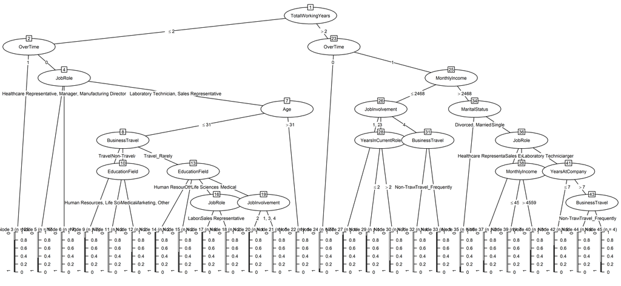

```r
set.seed(7)
# We load 'grid' package for manipulating some graphical parameters
library(grid)
# We show graphically the model
model_plot <- C5.0(train_dat[columns_for_model], train_dat$Attrition)
plot(model_plot, gp = gpar(fontsize = 7))
```

Now, for a fast evaluation of this model (that is only an initial model) we will create a confusion matrix.

```r
# We predict the results of the model in the training dataset
prediction <- predict(defalut_model, test_dat[columns_for_model])
# We calculate the accuracy of the model in the test dataset
100 * sum(prediction == test_dat$Attrition)/length(prediction)
```

```
## [1] 82.9932
```

```r
# We will use 'crosstable' function from the package 'gmodels' for creating the model
library(gmodels)
CrossTable(test_dat$Attrition, prediction, prop.chisq = FALSE, prop.c = FALSE, prop.r = FALSE,
    dnn = c("Reality", "Prediction"))
```

```
##
##
##    Cell Contents
## |-------------------------|
## |                       N |
## |         N / Table Total |
## |-------------------------|
##
##
## Total Observations in Table:  294
##
##
##              | Prediction
##      Reality |         0 |         1 | Row Total |
## -------------|-----------|-----------|-----------|
##            0 |       229 |        19 |       248 |
##              |     0.779 |     0.065 |           |
## -------------|-----------|-----------|-----------|
##            1 |        31 |        15 |        46 |
##              |     0.105 |     0.051 |           |
## -------------|-----------|-----------|-----------|
## Column Total |       260 |        34 |       294 |
## -------------|-----------|-----------|-----------|
##
##
```

The accuracy of the model is relatively high, however, the model doesn’t predict very well the class “1” (the employee left the organisation). For this class we had a lot of very specific rules, but, those rules probably were very specific to the train dataset, and is not applying to other cases.

We will try to solve this problem using pruning options, this will avoid creating overly complex ramifications, and will lead to more general rules that will likely be useful in various datasets.

```r
prunned_model <- C5.0(train_dat[columns_for_model], train_dat$Attrition, rules = TRUE, control = C5.0Control(noGlobalPruning = FALSE,
    CF = 0.1))

prunned_model
```

```
##
## Call:
## C5.0.default(x = train_dat[columns_for_model], y = train_dat$Attrition, rules = TRUE, control
##  = C5.0Control(noGlobalPruning = FALSE, CF = 0.1))
##
## Rule-Based Model
## Number of samples: 1176
## Number of predictors: 15
##
## Number of Rules: 8
##
## Non-standard options: attempt to group attributes, confidence level: 0.1
```

The number of rules has decreased from 17 to 8.

```r
summary(prunned_model)
```

```
##
## Call:
## C5.0.default(x = train_dat[columns_for_model], y = train_dat$Attrition, rules = TRUE, control
##  = C5.0Control(noGlobalPruning = FALSE, CF = 0.1))
##
##
## C5.0 [Release 2.07 GPL Edition]      Sat Aug 31 04:00:48 2024
## -------------------------------
##
## Class specified by attribute `outcome'
##
## Read 1176 cases (16 attributes) from undefined.data
##
## Rules:
##
## Rule 1: (573/41, lift 1.1)
##  Age > 31
##  OverTime = 0
##  ->  class 0  [0.927]
##
## Rule 2: (610/45, lift 1.1)
##  JobRole in {Healthcare Representative, Manager, Manufacturing Director,
##                     Research Director, Research Scientist, Sales Executive}
##  OverTime = 0
##  ->  class 0  [0.925]
##
## Rule 3: (775/66, lift 1.1)
##  OverTime = 0
##  TotalWorkingYears > 2
##  ->  class 0  [0.914]
##
## Rule 4: (969/114, lift 1.1)
##  MonthlyIncome > 2468
##  TotalWorkingYears > 2
##  ->  class 0  [0.882]
##
## Rule 5: (5, lift 5.3)
##  JobRole = Human Resources
##  TotalWorkingYears <= 2
##  ->  class 1  [0.857]
```

[output cut: 30 more lines]

```
##    ----  ----
##     960    25    (a): class 0
##     125    66    (b): class 1
##
##
##  Attribute usage:
##
##   93.62% TotalWorkingYears
##   86.90% MonthlyIncome
##   74.49% OverTime
##   55.53% JobRole
##   51.96% Age
##
##
## Time: 0.0 secs
```

The number of very specific rules has decreased. However, the rule that applied to the smallest number of cases in the last model, is still present here (Rule 5: JobRole = Human Resources; TotalWorkingYears <= 2). If we wanted, we could continue refining this model to find a better one. However, in this practical case we will stop here to avoid extending it excessively.

We will show graphically this model, for understanding visualy how it simplifyed.

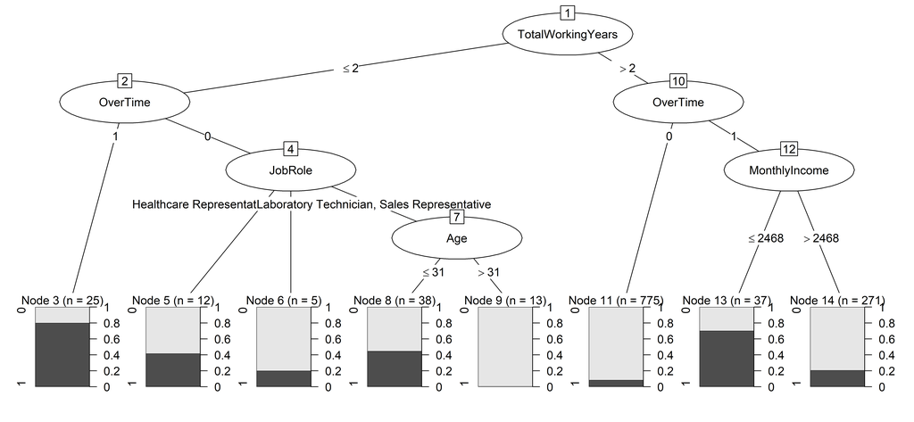

```r
prunned_model_plot <- C5.0(train_dat[columns_for_model], train_dat$Attrition, control = C5.0Control(noGlobalPruning = FALSE,
    CF = 0.1))

plot(prunned_model_plot, gp = gpar(fontsize = 12))
```

Now the model is much more understandable than before. If this model is also better (or equal) for predicting both classes, we will be able to say that pruning it was something positive.

We will now evaluate this model more thoroughly than the previous one.

## 7.3 - Evaluating the model.

For the evaluation we will create a function that will return all the metrics that we can obtain for evaluating supervised models.

```r
# The input of the function are all the values from the confusion matrix
calculateMetrics <- function(TP, TN, FP, FN) {
    # The function will calculate all the measures used for evaluating supervised models
    accuracy <- (TP + TN)/(TP + TN + FP + FN)
    specificity <- TN/(TN + FP)
    presicion <- TP/(TP + FP)
    sensitivity <- TP/(TP + FN)
    F_Measure <- 2 * ((presicion * sensitivity)/(presicion + sensitivity))

    # We print a formatted text showing all of these values
    cat(paste0("Accuracy: ", round(accuracy, 2), "\n", "Specificity: ", round(specificity,
        2), "\n", "Presicion: ", round(presicion, 2), "\n", "Sensitivity: ", round(sensitivity,
        2), "\n", "F-Measure: ", round(F_Measure, 2), "\n"))
}
```

Now we will use this function with the confusion matrix of this model.

```r
# We make predictions with the pruned model
prediction_pruned <- predict(prunned_model, test_dat[columns_for_model])
# We show the confusion matrix
CrossTable(test_dat$Attrition, prediction_pruned, prop.chisq = FALSE, prop.c = FALSE, prop.r = FALSE,
    dnn = c("Reality", "Prediction"))
```

```
##
##
##    Cell Contents
## |-------------------------|
## |                       N |
## |         N / Table Total |
## |-------------------------|
##
##
## Total Observations in Table:  294
##
##
##              | Prediction
##      Reality |         0 |         1 | Row Total |
## -------------|-----------|-----------|-----------|
##            0 |       226 |        22 |       248 |
##              |     0.769 |     0.075 |           |
## -------------|-----------|-----------|-----------|
##            1 |        31 |        15 |        46 |
##              |     0.105 |     0.051 |           |
## -------------|-----------|-----------|-----------|
## Column Total |       257 |        37 |       294 |
## -------------|-----------|-----------|-----------|
##
##
```

If we compare this confusion matrix with the previous one, the results of this model are slightly worse, because this model makes some more false positives -22 vs 19 that were before-, but considering that is a much more simple model, we will not consider this as an important problem.

Now we use the function.

```r
calculateMetrics(15, 226, 22, 31)
```

```
## Accuracy: 0.82
## Specificity: 0.91
## Presicion: 0.41
## Sensitivity: 0.33
## F-Measure: 0.36
```

The value of the **specificity** (0.91) is higher than the accuracy, which indicates that the model is better for predicting the negative class than the positive. On the other hand, the low values of the **precision** (0.41) and the **sensitivity** (0.33) are indicating that the model is not very good at detecting the positive class.

These results represent a limitation for the situations where the model can be used. For specific detections of the positive class (i.e. determining which case will be positive), this model is contraindicated as could make mistakes, and lead to discrimination in the company that uses the model this way. However, this model could be useful for descriptive situations where the goal is to identify situations where the risk of attrition is low or high.

## 7.4 - Posible improvements for the development of a better model.

Given that this model has a low value in the F-Measure, is possible to improve it, and having better general results for predicting both classes (and even, if the precision were much higher, it would be possible to use this model for more specific situations and not only for general descriptions of the situation of an organisation).

The principal problem may stem from the unbalanced classes (there are much more cases of the negative than of the positive). Balancing them is mandatory for a better performance, some techniques for creating synthetic observation should be used, such as SMOTE (Synthetic Minority Over Sampling Technique) or ADASYN (Adaptive Synthetic Sampling Approach).

Additionaly, a more thorough tuning of the model parameters model should be done. Using a grid search strategy with multiple combinations of values of the parameters of the model, combined with creating new synthetic observations, would possibly bring to find the best model for this data. If this strategy is not bringing significantly better models, new data shold be collected, specially about the positive class.

# 8 - LOGISTIC REGRESION MODEL

We attempted to use mutiple relatively complex models, and the results were not very satisfactory (the decision tree model is not effective at identifying the positive class, the hierarchical clustering has a very low average silhouette even in the best obtained result, and the DBSCAN algorithm finds only one cluster, which makes unclear if this method is much better than just using a multivariate outlier detection method).

Therefore, we will use a simpler model, the logistic regression. This will serve as a benchmark. If other models are trained, they should at least work better than this one to be considered an improvement.

**Note.**

The best way to train this model is to verify all the statistical assumptions of the model, and only use the model if they are met. However, since we are using cross validation to evaluate its performance, we will accept not verifying them if the model performs well with other data than the training data. However, in a real scenario, where critical problems are analysed, it is not a good practice to use the model without meeting the statistical assumptions.

## 8.1 - Creating the model

```r
set.seed(7)
# We create a lineal model with the 'glm' function from the binomial family, and using
# all the variables from the training dataset
logictic_model <- glm(Attrition ~ ., data = train_dat, family = binomial)
# We show a summary of the model
summary(logictic_model)
```

```
##
## Call:
## glm(formula = Attrition ~ ., family = binomial, data = train_dat)
##
## Coefficients:
##                                   Estimate Std. Error z value Pr(>|z|)
## (Intercept)                     -2.045e+00  1.223e+00  -1.672 0.094446 .
## Age                             -1.984e-02  1.415e-02  -1.402 0.160912
## BusinessTravelTravel_Rarely      4.990e-01  3.581e-01   1.393 0.163517
## BusinessTravelTravel_Frequently  1.301e+00  3.887e-01   3.346 0.000819 ***
## EducationFieldLife Sciences     -4.371e-02  8.210e-01  -0.053 0.957540
## EducationFieldMarketing          5.191e-01  8.715e-01   0.596 0.551454
## EducationFieldMedical           -8.784e-02  8.258e-01  -0.106 0.915287
## EducationFieldOther             -1.843e-01  8.810e-01  -0.209 0.834308
## EducationFieldTechnical Degree   9.539e-01  8.506e-01   1.122 0.262068
## JobInvolvement2                 -7.793e-01  3.765e-01  -2.070 0.038452 *
## JobInvolvement3                 -1.197e+00  3.603e-01  -3.323 0.000890 ***
## JobInvolvement4                 -1.571e+00  4.949e-01  -3.174 0.001506 **
## JobLevel                        -4.448e-02  3.151e-01  -0.141 0.887756
## JobRoleHuman Resources           1.425e+00  7.035e-01   2.025 0.042835 *
## JobRoleLaboratory Technician     1.603e+00  5.281e-01   3.036 0.002400 **
## JobRoleManager                  -1.900e-01  8.173e-01  -0.232 0.816176
## JobRoleManufacturing Director   -7.369e-02  5.885e-01  -0.125 0.900345
## JobRoleResearch Director        -1.915e+00  1.216e+00  -1.574 0.115483
## JobRoleResearch Scientist        7.852e-01  5.370e-01   1.462 0.143700
## JobRoleSales Executive           1.043e+00  4.770e-01   2.187 0.028772 *
## JobRoleSales Representative      2.165e+00  6.080e-01   3.561 0.000370 ***
## MaritalStatusMarried             3.318e-01  3.047e-01   1.089 0.276088
## MaritalStatusSingle              4.288e-01  4.197e-01   1.022 0.306985
## MonthlyIncome                    5.809e-05  8.287e-05   0.701 0.483317
## OverTime1                        1.701e+00  1.974e-01   8.618  < 2e-16 ***
## StockOptionLevel1               -9.746e-01  3.224e-01  -3.023 0.002504 **
## StockOptionLevel2               -1.199e+00  4.656e-01  -2.575 0.010017 *
## StockOptionLevel3               -3.688e-01  4.840e-01  -0.762 0.446128
## TotalWorkingYears               -1.849e-02  2.869e-02  -0.644 0.519372
## YearsAtCompany                   4.172e-02  3.750e-02   1.112 0.265925
## YearsInCurrentRole              -1.044e-01  4.878e-02  -2.139 0.032396 *
## YearsWithCurrManager            -4.155e-02  5.042e-02  -0.824 0.409901
## Low_satisfaction1                1.172e+00  2.788e-01   4.203 2.63e-05 ***
## ---
## Signif. codes:  0 '***' 0.001 '**' 0.01 '*' 0.05 '.' 0.1 ' ' 1
##
## (Dispersion parameter for binomial family taken to be 1)
##
##     Null deviance: 1043.47  on 1175  degrees of freedom
## Residual deviance:  766.28  on 1143  degrees of freedom
## AIC: 832.28
##
## Number of Fisher Scoring iterations: 7
```

This summary shows us which variables are statistically significant in the prediction, and the contribution of each variable (in the “Estimate” column). The values from this summary are used to predict the probability of each observation belonging to a particular class. Now we will make predictions with the model.

## 8.2 - ROC curve of the model

```r
predictions <- predict(logictic_model, newdata = test_dat, type = "response")
head(predictions)
```

```
##          1          8         11         17         33         35
## 0.33381554 0.06797078 0.03604116 0.06559366 0.27039335 0.19744273
```

These predictions indicate the probability that the model assigns to each observation of being positive. To determine the class of each observation, we will establish a cut-off point for the predictions. If an observation has a probability equal to or higher than this point, it will be classified as positive (class 1), but if it has a lower value, it will be classified as negative.

To decide the value of this point, we will visualize the ROC curve of this model.

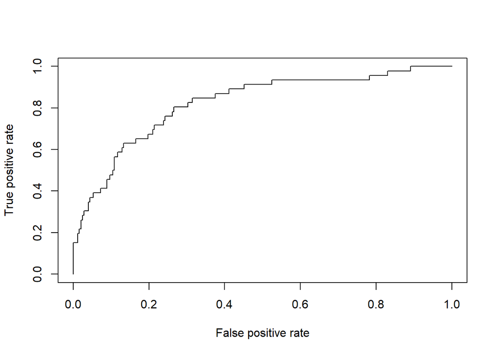

```r
# We will use the 'ROCR' library for evaluate the model
library(ROCR)
# We will create a 'prediction' object with which we will use the 'performance' function
# for evaluating it
prediction <- prediction(predictions, test_dat$Attrition)
prf <- performance(prediction, measure = "tpr", x.measure = "fpr")
# We graphically show the performance of the model
plot(prf)
```

This ROC curve is moved away from the diagonal, to the upper left corner. This is something positive because it means that while the cut-off point increases, the false positives increment is slower than the true positives increment. For example, in this graph we can see a zone where the rate of false positives is still quite low (around 0.4), but the true positive rate is much more higher (around 0.8).

We will try to create a model which obtains these results. For this, we will transform the values of the probabilities in 0 and 1 using different cut-off points, and establishing confusion matrices with the obtained values and the real values of the “Attrition” variable.

## 8.3 - Searching a balanced model

**We start trying a cut-off point of 0.5**

```r
prediction_data <- ifelse(predictions > 0.5, 1, 0)
# We create a confusion matrix with the obtained predictions
table(test_dat$Attrition, prediction_data)
```

```
##    prediction_data
##       0   1
##   0 240   8
##   1  32  14
```

This model performs better than the previous decision tree in predicting class 0, correctly identifying 240 cases compared to 226 that predicted the previous decision tree, while predicting a similar number of class 1 cases (14 vs. 15). It also reduces false positives from 22 to 8, making it a slightly better model overall. However, we will test other cut-off points to improve predictions for the positive class by lowering the threshold for classifying an observation as positive.

**We try a cut-off point of 0.25**

```r
prediction_data <- ifelse(predictions > 0.25, 1, 0)
# We create a confusion matrix with the obtained predictions
table(test_dat$Attrition, prediction_data)
```

```
##    prediction_data
##       0   1
##   0 213  35
##   1  17  29
```

The number of cases predicted as positive has increased, and the number of cases predicted as negative has decreased. However, the number of correct cases predicted as class 0 has not decreased a lot, but the number of cases correctly classified as class 1 is twice as many as with the previous cut-off point value. Nevertheless, the number of false positives has increased by a higher proportion.

Even so, depending on the use given to the model, this may not necessarily be negative. If it is more important to maximize the number of positive cases detected than minimizing the number of cases incorrectly classified as positive, then this model can be useful in this case.

**We try a cut-off point of 0.2**

```r
prediction_data <- ifelse(predictions > 0.2, 1, 0)
# We create a confusion matrix with the obtained predictions
table(test_dat$Attrition, prediction_data)
```

```
##    prediction_data
##       0   1
##   0 195  53
##   1  14  32
```